# Multistate Intensity Models with Deep Architectures

**Table of Contents**

1. Introduction
2. Data

   2.1 Monthly Performance Data

   2.2 Origination Data

   2.3 Merged Data
3. Methodologies

   3.1 Benchmark Model

   3.2 Semi-Structured Deep Distributional Regression (SDDR)
4. Applications:

   4.1 Benchmark model

   4.2 Semi-Structured Deep Distributional Regression Model
5. Alternative Approaches

   5.1 RNN-based architectures

   5.2 Conditional Random Fields

   5.3 Transformer-based methods and beyond
6. Conclusions and Discussions

## 0. Setting up the environment

1. Download our repo [here](https://github.com/stw2/Topic-6-Multistate-Intensity-Models-with-Deep-Architectures.git).
2. Put the data under "Multistate Intensity Models/data/.
3. Download [PySDDR](https://github.com/HelmholtzAI-Consultants-Munich/PySDDR.git) and put under "Multistate Intensity Models/".

This computational notebook has been tested to run on local machines and Google Colab (both require Python 3.7 or later). Please put this notebook under the folder "Multistate Intensity Models/" before running it.

```python
# check package versions
!pip list -v | grep numpy # == 1.21.5
!pip list -v | grep scipy # == 1.7.3
!pip list -v | grep matplotlib # == 3.5.1
!pip list -v | grep pandas # >= 1.3.5
!pip list -v | grep scikit-learn # == 1.0.1
!pip list -v | grep imbalanced-learn # == 0.9.0
!pip list -v | grep torch* # >= 1.10.0
```

```python
# install required package versions if requirements not met
!pip install numpy==1.21.5
!pip install scipy==1.7.3
!pip install matplotlib==3.5.1
!pip install scikit-learn==1.0.1
!pip install -U imbalanced-learn==0.9.0
# then restart runtime
```

```python
# import packages
from copy import deepcopy
import joblib
import os
import sys

import numpy as np
import pandas as pd

from scipy.stats import uniform
from scipy.special import expit

from sklearn.compose import ColumnTransformer
from sklearn.linear_model import LogisticRegression
from sklearn.metrics import roc_auc_score, roc_curve
from sklearn.model_selection import GridSearchCV, RandomizedSearchCV, StratifiedShuffleSplit
from sklearn.preprocessing import SplineTransformer, StandardScaler
from sklearn.utils.fixes import loguniform

import warnings
from sklearn.exceptions import ConvergenceWarning

import seaborn as sns
import matplotlib.pyplot as plt

from copy import deepcopy
import joblib

import pandas as pd
import numpy as np
```

```python
# load google drive if you run the notebook on Google Colab
from google.colab import drive
drive.mount('/content/drive')
```

```python
# install PySDDR from google drive if not already installed
!pip install "/content/drive/My Drive/Multistate Intensity Models/PySDDR/"
# or on local machines
# !pip install "/path/to/Multistate Intensity Models/PySDDR/"
```

```python
# import customized packages
sys.path.append("/content/drive/My Drive/Multistate Intensity Models/")
# or on local machines
# sys.path.append("/path/to/Multistate Intensity Models/SIS_WS2122/")
from sisutils.ApplyBMModel import ApplyBMModel
from sisutils.SddrEstimator import SddrEstimator
from sisutils.TransitionProbaMatrix import TransitionProbaMatrix
```

```python
# change the plot settings
%matplotlib inline
plt_params = {'mathtext.default':'regular'}
plt.rcParams.update(plt_params)
```

## 1. Introduction

An accurate prediction of the probability of delinquency or default of loans is extremely crucial for financial or government institutions. Various models have been implemented to predict the default risk of loans and the most common one is the static regression models. The static cross-section model, which is only valid for a predefined outcome period, suffers from two deficiencies (Leow & Crook, 2014): 1) it ignores the accounts that have been closed or not yet experienced the event during the defined period; 2) it cannot adequately incorporate time-varying features such as macroeconomic variables.

Models built on survival analysis are able to deal with the censored data. Application of survival models to quantify the credit risk can be found in for example in Bellotti and Crook (2013) and Luo et al. (2016). However, survival models are based on the assumption that the risk of occurrence of each event is independent until an event actually arises. This assumption may be questionable because the repayment behavior of borrowers might change during the lifetime of the loans, thus exerting influence on how the default risk changes (Leow & Crook, 2014).

There are several advantages associated with the application of the multistate intensity model in credit scoring (Leow & Crook, 2014; Djeundje & Crook, 2018). From a theoretical perspective, the intensity model is more dynamic than the cross-section regression model in the sense that it can take time-varying features into account. In comparison with the survival model, the intensity model enables us to predict not only the hazard probability of default but also the transition probabilities for in-between states. Consequently, a non-homogenous probability transition matrix can be generated. From a practical view, the intensity model can help financial institutes to gain more insights into the progress of loans. Such kind of knowledge is essential in improving the accuracy of the assessment of risks, quantifying the expected cash flow and etc.

In the present problem setting, one can extend the multistate intensity model with deep architectures by adding a neural network component to each of the model equations modeling the transition probabilities. Or by framing the generalized linear or additive models as a shallow network with activate functions being the link functions or neurons mimicking generic functions in the additive models and combining the shallow network with the desired deep neural networks. However, most of the approaches face the issue of unidentifiability in that neural networks and linear models both learn linear effects of the features if provided an overlapping set of features as inputs. (for a brief review, see Rügamer et al., 2020). If the interpretability of the multistate intensity model is lost due to the incorporation of deep structures, one can turn to other deep learning solutions that deal with non-homogenous state transitions. Fortunately, Semi-Structured Deep Distributional Regression (SDDR) tackles unidentifiability with orthogonalization (Rügamer et al., 2020). In this essay, we use SDDR models to explore whether deep architectures help improve the predictions of the multistate intensity model.

Multistate intensity models are also widely used outside the financial and lending industry. A vast body of research in this field comes from the medical world. Medical conditions can be described, for example, as healthy, diseased, or deceased (absorbing event). Predicting the time until an event of interest is of crucial importance in medicine as, for example, it allows for better management of intensive care units (ICUs) or it can provide more accurate and personalized prognostics for cancer patients (see Yu et al., 2011). For a comprehensive review of the application of traditional multistate models in the medical field, one can consult the review by Hougaard (1999). Moreover, various deep learning techniques for time-to-event problems were also proposed within medical research, for example, DeepSurv (Katzman et al., 2018), DeepHit (Lee et al., 2018), or RNN-SURV (Giunchiglia et al., 2018). Furthermore, other applications of time-to-event modeling are product reliability modeling (e.g. see Aminisharifabad et al., 2021), customer lifetime estimation (e.g. Jing & Smola, 2017) or modeling economic phenomena (see the overview by Danacica & Babucea, 2010) just to name a few.

The benefits of using multistate models in comparison with standard survival modeling depend on the application and the data under consideration. However, intensity models excel at analyzing survival data where intermediate events and multiple results are possible. Over the last few years, there has been increasing interest in more sophisticated models that take into account intermediary states (non-fatal) as well as more complex relationships between them (Groha et al., 2020).

This computational notebook is structured as follows: Section 2 describes how we processed the dataset from US Federal Home Loan Mortgage Corporation. We present our methodologies in Section 3 and describe the application of the benchmark model and Semi-Structured Deep Distributional Regression Model in Section 4. In Section 5, several alternative deep learning approaches to multistate modeling are presented. The last section summarizes and discusses the results.

## 2. Data

```python
# import data
os.chdir("/content/drive/My Drive/Multistate Intensity Models/") # not needed when run on local machines
df_covs = pd.read_csv('data/fmac_sample_2015_covs.csv', sep=',')
df_trans = pd.read_csv('data/fmac_sample_2015_trans.csv', sep=',')

# check the number and time span of the loans
df_trans['period'] = pd.to_datetime(df_trans['period'], format='%Y%m', errors='coerce')
yr_min = df_trans['period'].dt.year.min()
yr_min_mth = df_trans['period'][df_trans['period'].dt.year == yr_min].dt.month.min()
yr_max = df_trans['period'].dt.year.max()
yr_max_mth = df_trans['period'][df_trans['period'].dt.year == yr_max].dt.month.max()
print(f'There are {df_trans.shape[0]} loan accounts and the earliest and last repayment are in {yr_min}.{yr_min_mth} and {yr_max}.{yr_max_mth}, respectively.')
```

```
There are 2460454 loan accounts and the earliest and last repayment are in 2015.3 and 2021.6, respectively.
```

### 2.1 Monthly Performance Data

The feature `id_loan` includes the loan sequence number that acts as a unique identifier for each loan. To extract more information from this feature, we convert each value in `id_loan` into strings. As shown by the output, all the loans in the dataset are fixed rate mortgage loans.

```python
# convert `id_loan` to string
df_trans['id_loan'] = df_trans['id_loan'].astype('str')

# Check how many loans that are not FRM
print(f'Number of loans that are not FRM: {df_trans.shape[0] - df_trans["id_loan"].apply(lambda x: np.char.startswith(x, "F")).sum()}')
```

```
Number of loans that are not FRM: 0
```

The feature `current_upb` stands for the current actual unpaid principal balance (UPB), which reflects the loan ending balance for each monthly reporting period. The kernel density estimate (KDE) plot is wiggly at two ends and 50% of the data lies between 110.11 and 260.1 thousand dollars.

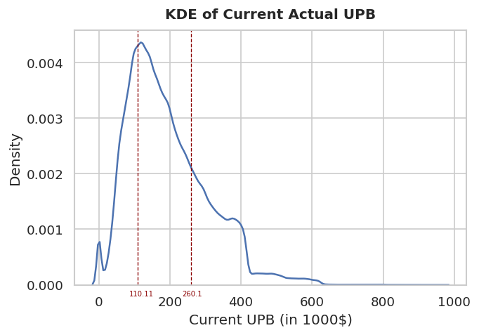

```python
# check the distribution of `current_upb`
plt.rcParams['figure.dpi'] = 120
plt.rcParams['figure.figsize'] = (6, 4)
sns.set_theme(style='whitegrid')
plt.title('KDE of Current Actual UPB', fontweight='bold', fontsize=12, pad=10)
sns.kdeplot(data=df_trans['current_upb']/1000).set(xlabel='Current UPB (in 1000$)')
for q in df_trans['current_upb'].quantile([0.25, 0.75])/1000:
    plt.axvline(q, color='darkred', linestyle='dashed', linewidth=0.8)
    plt.text(q-25, -0.0002, str(round(q, 2)), fontsize=6, color='darkred')
plt.show();
```

Following Leow & Crook (2014), we define four states in the life of a mortgage loan. An up-to-date loan account is in state 0. State 1 or 2 means that the loan is in one or two months in arrears, respectively. If one debtor misses payments for three months—whether consecutively or not, the corresponding loan account enters default. As shown in the output below, the majority of the cases stayed up to date. The numbers of cases in one, two, and three arrears decrease monotonically.

```python
# check the delinquency status
tmp = df_trans['delq_sts'].value_counts().sort_index()
pd.DataFrame({'count': tmp, 'frequency': tmp/df_trans.shape[0]})
```

|  | count | frequency |
| --- | --- | --- |
| 0 | 2441072 | 0.992123 |
| 1 | 14123 | 0.005740 |
| 2 | 3546 | 0.001441 |
| 3 | 1713 | 0.000696 |

In each period, a loan account can move forward at most one step to the later state; however, the number of steps to lower state is not restricted. Inspired by Leow & Crook (2014), we use the following figure to illustrate transitions of states for three selected loan accounts.

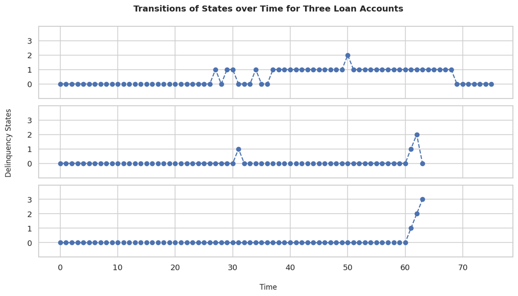

```python
plt.rcParams['figure.figsize'] = (12, 6)
plt.rcParams['figure.dpi'] = 120
fig, axes = plt.subplots(3, 1, sharex='col')
plt.suptitle(t='Transitions of States over Time for Three Loan Accounts', y=0.95, fontweight='bold', fontsize=12)
fig.text(0.5, 0.02, 'Time', ha='center', fontsize=10)
fig.text(0.07, 0.5, 'Delinquency States', va='center', rotation='vertical', fontsize=10)
fig.subplots_adjust(hspace=0.1)
sts_sample = ['F15Q10005276', 'F15Q10007515', 'F15Q10009966']
for i in range(3):
    axes[i].set_yticks(range(4))
    axes[i].set_ylim(-1, 4)
    axes[i].plot(df_trans[df_trans['id_loan'] == sts_sample[i]]['time'], df_trans[df_trans['id_loan'] ==  sts_sample[i]]['delq_sts'], marker='o', linestyle='dashed')
plt.show()
```

To predict the transition probabilities, we define six events: `event_01`, `event_10`, `event_12`, `event_20`, `event_21`, `event_23`. With the bar plot below, we can have a first impression of some types of transitions. If an observation was in state 1 in the previous period, then this observation is more likely to have a recovery (i.e., more back to state 0) than to advance into the next delinquency state. However, if an observation is already in state 2, the chance that it will enter default in the next period is large.

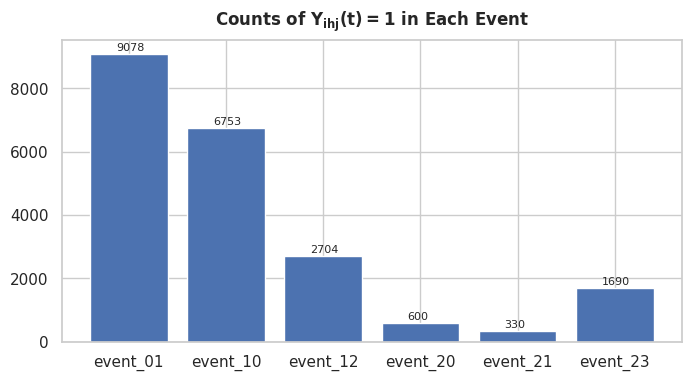

```python
# convert NaN in `event_hj` to 0 (integer)
events = ['event_'+ i for i in ['01', '10', '12', '20', '21', '23']]
df_trans[events] = df_trans[events].fillna(0, downcast='infer')

# visualize the number of cases of each event
event_freq = df_trans[events].sum(axis=0)
plt.rcParams['figure.figsize'] = (8, 4)
plt.rcParams['figure.dpi'] = 100
plt.title(r'Counts of $Y_{ihj}(t)=1$ in Each Event', fontweight='bold', fontsize=12, pad=10)
event_bar = plt.bar(x=events, height=event_freq)
for (i, freq) in zip(event_bar, event_freq):
    plt.text(i.get_x() + i.get_width()/3, freq+100, str(freq), fontsize=8)
plt.show()
```

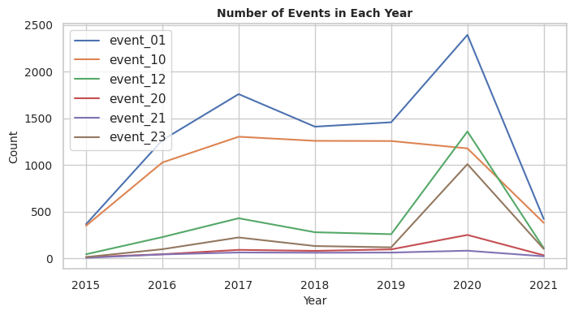

```python
# calculate the number of events by year
df_event_by_year = df_trans.groupby(df_trans['period'].dt.year)[events].sum()

# visualize the counts
fig, ax = plt.subplots()
plt.rcParams['figure.figsize'] = (12, 5)
plt.rcParams['figure.dpi'] = 120
plt.title('Number of Events in Each Year', fontweight='bold', fontsize=10)
plt.xticks(size=10)
plt.yticks(size=10)
plt.xlabel('Year', fontsize=10)
plt.ylabel('Count', fontsize=10)
for i, event in enumerate(events):
    ax.plot(df_event_by_year.index, df_event_by_year[event], label=event)
    ax.legend(loc='upper left')
```

Next we would like to check whether there are missing values in variables in the dataframe `df_trans` (`events` are excluded). As suggested by the output, we have complete data for the as-of month for loan information, the current UPB, and the delinquency states.

```python
# check number of missing values
df_trans.drop(columns=events).isna().sum(axis=0)
```

```
id_loan        0
period         0
current_upb    0
delq_sts       0
time           0
dtype: int64
```

### 2.2 Origination Data

Let's first discuss the numerical features in the origination data file. Note that we also include `current_upb` in `var_n` for further data processing, although `current_upb` actually belongs to the monthly performance data. A short description of each feature that we might include in our models is presented in the following table. We leave out `dt_first_pi` (first payment date) and `dt_matr` (maturity date) in the original dataset because they repeat the same information that has already been included in `period` or `time`.

```python
# create array for numerical features
var_n = np.array(['fico', 'mi_pct', 'cnt_units', 'cltv', 'ltv', 'dti', 'current_upb', 'orig_upb', 'int_rt', 'orig_loan_term'])
pd.DataFrame(
    {'feature': np.delete(var_n, 6),
     'name': ['credit score', 'mortgage insurance percentage', 'number of units of mortgage property', 'original combined loan-to-value', 'original loan-to-value', 'original debt-to-income ratio', 'original UPB', 'original interest rate', 'original loan term']}
)
```

|  | feature | name |
| --- | --- | --- |
| 0 | fico | credit score |
| 1 | mi_pct | mortgage insurance percentage |
| 2 | cnt_units | number of units of mortgage property |
| 3 | cltv | original combined loan-to-value |
| 4 | ltv | original loan-to-value |
| 5 | dti | original debt-to-income ratio |
| 6 | orig_upb | original UPB |
| 7 | int_rt | original interest rate |
| 8 | orig_loan_term | original loan term |

According to the user guide of the dataset, extreme values in `fico` and `mi_pct` are set to be 9999 and 999, respectively. The missing values in `cnt_units`, `cltv`, `ltv`, and `dti` are labeled with 99 or 999. To make the calculation of the proportion of missing values in these features easier, we replace 99, 999, or 9999 with `np.NaN`. We use a heatmap to visualize the distribution of the missing values in each feature.

```
fico: 1 (0.002%)
mi_pct: 0 (0.000%)
cnt_units: 0 (0.000%)
cltv: 1 (0.002%)
ltv: 1 (0.002%)
dti: 3984 (8.493%)
```

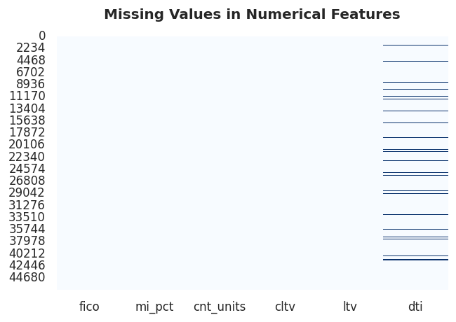

```python
# convert 99/999/9999 to `np.NaN`
df_covs = df_covs.replace(to_replace={'fico': 9999, 'mi_pct': 999, 'cnt_units':99, 'cltv':999, 'ltv': 999, 'dti': 999}, value=np.NaN)

# check the proportion of loan that does not have available data for `fico`, `mi_pct`, `cnt_units`, `cltv`, `ltv`, and `dti`
tmp = df_covs[var_n[:6]].isna().sum()
for i, var in enumerate(var_n[:6]):
    print(f'{var}: {tmp[i]} ({tmp[i]/df_covs.shape[0]*100:.3f}%)')

# visualize the distribution of missing values
plt.rcParams['figure.figsize'] = (6, 4)
plt.title('Missing Values in Numerical Features', fontweight='bold', fontsize=12, pad=15)
plt.xticks(size=10); plt.yticks(size=10)
sns.heatmap(df_covs[var_n[:6]].isna(), cbar=False, cmap='Blues');
```

The output shows that `fico`, `cltv`, `ltv`, and `dti` have missing values and only `dti` includes a relatively large number of unavailable values, which seem to be randomly distributed in the dataset according to the heatmap. It is worth noticing that in the benchmark model and the SDDR model, we will assume that observations of one loan account at different times are independent. Therefore, the number of missing values will inflate. After splitting the whole dataset into training and test data, we will replace the missing values in `fico`, `cltv`, `ltv`, and `dti` with the median of each variable in the corresponding subsets of training data.

We use boxplots the check the distribution of the numerical variables, when the missing values are excluded. As shown in the figure, most variables include a considerable number of outliers even when the original data file compiles extreme value with 99/999/9999. We decide not to replace the outliers in a feature with other values because we do not want to artificially include any new bias into the data. The median of the credit score in the entire dataset is slightly above 750. Most of the mortgage loans in the dataset do not have loss coverage and the percentage mortgage insurance (`mi_pct`) is more discrete than continuous. The majority of the mortgage is one-unit property. It is natural that the distributions for `cltv` and `ltv` are quite similar since there are overlaps in the calculation of them. The median of original UPB (`orig_upb`) is ca. 200,000 US dollars and the median of the interest rate (`int_rt`) is 4%. The median of the original loan term is also the maximum.

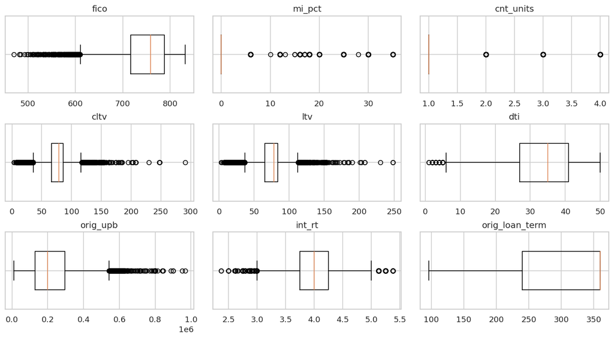

```python
# create boxplots (outlier: < Q1-1.5IQR, > Q3+1.5IQR)
fig, axes = plt.subplots(3, 3, figsize=(5*3, 2.5*3))
fig.subplots_adjust(wspace=0.1, hspace=0.4)
tmp = [0, 1, 2]*3
for i, var in enumerate(np.delete(var_n, 6)):
    axes[i//3, tmp[i]].set_title(var, size=12)
    axes[i//3, tmp[i]].set_yticks([0], None)
    axes[i//3, tmp[i]].boxplot(df_covs[var].dropna(), sym='o', vert=False, widths=0.5)
plt.show()
```

There are 19 categorical features in the dataset. Spatial features will be discussed separately later, and we provide a short description for all the other categorical variables in the following table.

```python
# create an array for categorical features (except 3 spatial features)
var_c_1 = np.array(['flag_fthb', 'occpy_sts', 'channel', 'ppmt_pnlty', 'prod_type', 'prop_type', 'loan_purpose', 'cnt_borr', 'seller_name', 'servicer_name', 'flag_sc', 'pre_harp', 'program_ind', 'harp_ind', 'prop_val_meth', 'int_only_ind'])

pd.DataFrame(
    {'feature': var_c_1,
     'name': ['first time homebuyer flag', 'occupancy status (mortgage type)', 'entity involved in the origination of the mortgage loan', 'prepayment penalty mortgage (PPM) flag', 'amortization type', 'property type', 'purpose of the mortgage', 'number of borrowers', 'entity acting as a seller of mortgages', 'entity acting as a servicer of mortgages', 'super conforming flag', 'pre-HARP loan sequence numer', 'program indicator', 'HARP indicator', 'property valuation method', 'interest only indicator ']}
)
```

|  | feature | name |
| --- | --- | --- |
| 0 | flag_fthb | first time homebuyer flag |
| 1 | occpy_sts | occupancy status (mortgage type) |
| 2 | channel | entity involved in the origination of the mort... |
| 3 | ppmt_pnlty | prepayment penalty mortgage (PPM) flag |
| 4 | prod_type | amortization type |
| 5 | prop_type | property type |
| 6 | loan_purpose | purpose of the mortgage |
| 7 | cnt_borr | number of borrowers |
| 8 | seller_name | entity acting as a seller of mortgages |
| 9 | servicer_name | entity acting as a servicer of mortgages |
| 10 | flag_sc | super conforming flag |
| 11 | pre_harp | pre-HARP loan sequence numer |
| 12 | program_ind | program indicator |
| 13 | harp_ind | HARP indicator |
| 14 | prop_val_meth | property valuation method |
| 15 | int_only_ind | interest only indicator |

Similar to the procession of numerical variables, the numbers used to indicate missing values are replaced with `np.NaN`.

```python
# replace 9/99 with `np.NaN`
df_covs = df_covs.replace(to_replace={'flag_fthb': 9, 'occpy_sts': 9, 'channel': 9, 'prop_type':99, 'loan_purpose': 9, 'cnt_borr': 99, 'program_ind': 9, 'prop_val_meth': 9}, value=np.NaN)

# check the number of missing values
tmp = df_covs[var_c_1].isna().sum(axis=0).sort_values(ascending=False)/df_covs.shape[0]
tmp[tmp>0]
```

```
prop_val_meth    1.000000
flag_sc          0.962737
pre_harp         0.915114
harp_ind         0.915114
dtype: float64
```

The proportion of accounts that have missing values for each categorical feature are shown in the table above. There are four features with missing values. However, according to the user guide of the original data, the space in variable `flag_sc` and `harp_ind` actually means "No"; therefore, we will fill the space with `N`. The variable `prop_val_meth` does not have any valid values; thus we can exclude it from our models. The procession of `pre_harp` follows a closer look at the data.

```python
# exclude `prop_val_meth`
var_c_1 = np.delete(var_c_1, var_c_1=='prop_val_meth')

# change NaN to 'N' in 'flag_sc', 'pre_harp',and 'harp_ind'
df_covs[['flag_sc', 'harp_ind']] = df_covs[['flag_sc', 'harp_ind']].fillna('N')
```

Because variables with no variation cannot contribute to the prediction of the target and variables with high cardinality can give rise to the curse of dimensionality, we would like to check the number of levels of each categorical feature.

```python
# calculate levels of each variable in `var_c_1`
n_levels = df_covs[var_c_1].nunique()

# save the name of variables that have level=1, level=2, level>2
var_c_level = [var_c_1[n_levels <= 1], var_c_1[n_levels == 2], var_c_1[n_levels > 2]]

# print the results
levels = ['<= 1', '= 2', '> 2']
for i in range(3):
    print(f'level {levels[i]}: {var_c_level[i]}')

# delete variables whose level is less than one
var_c_1 = [var for var in var_c_1 if var not in var_c_level[0]]
```

```
level <= 1: ['ppmt_pnlty' 'prod_type' 'int_only_ind']
level = 2: ['flag_fthb' 'cnt_borr' 'flag_sc' 'program_ind' 'harp_ind']
level > 2: ['occpy_sts' 'channel' 'prop_type' 'loan_purpose' 'seller_name'
 'servicer_name' 'pre_harp']
```

As shown in the output, each of `ppmt_pnlty`, `prod_type`, and `int_only_ind` has a cardinality less than one. We will exclude them from our models.

```python
# check the levels of binary categorical features
for i in range(5):
    print(f'{var_c_level[1][i]}: {df_covs[var_c_level[1][i]].unique()}')
```

```
flag_fthb: ['N' 'Y']
cnt_borr: [2 1]
flag_sc: ['N' 'Y']
program_ind: ['9' 'H']
harp_ind: ['N' 'Y']
```

The levels `Y` ("yes") and `N` ("no") in `flag_fthb`, `flag_sc`, and `harp_ind` indicate whether the borrower or one of a group of borrowers is first-time homebuyers, whether the mortgages exceed conforming loan limits, and whether the loans belong to Home Affordable Refinance Program (HARP), respectively. The number `1` and `2` in `cnt_borr` reflect whether there are one or more than two borrowers who are obligated to repay the mortgage note. We rename the levels to make possible the incorporation of them into the SDDR model. According to the user guide of the data, `H` in `program_ind` means that the given loan takes part in the Home Possible or Home Possible Advantage program while `9` indicates that the loan does not participate in an affordable program. For consistency of coding, we replace `H` and `9` with `Y` and `N`, accordingly. We create pie plots to show the relative frequencies of the levels in binary features.

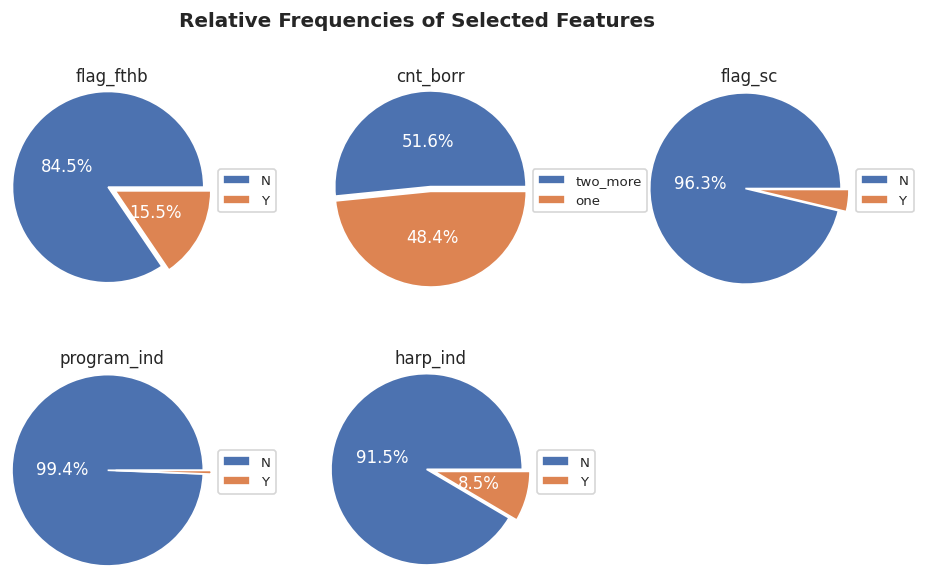

```python
# change the names of the levels of 'cnt_borr' and 'program_ind'
df_covs['program_ind'] = df_covs['program_ind'].replace(to_replace=['9','H'], value=['N','Y'])
df_covs['cnt_borr'] = df_covs['cnt_borr'].replace(to_replace=[2, 1], value=['two_more', 'one'])

# visualize the relative frequencies of levels in binary feature
fig, axes = plt.subplots(2, 3, figsize=(3*3, 3*2))
fig.delaxes(axes[1][2])
fig.subplots_adjust(wspace=0.6, hspace=-0.1)
tmp = [0, 1, 2]*3
fig.suptitle('Relative Frequencies of Selected Features', fontweight ='bold', size=12)
fig.subplots_adjust(top=0.95)
def show_autopct(pct):
    return ('%1.1f%%' % pct) if pct > 8 else None
for i, var in enumerate(var_c_level[1]):
    if var != 'cnt_borr':
        bi_counts = df_covs[var].value_counts()
        axes[i//3, tmp[i]].set_title(var, size=10, pad=5)
        axes[i//3, tmp[i]].pie(bi_counts, explode=np.repeat(0.05, len(bi_counts)), radius=1.2, autopct=show_autopct, pctdistance=0.48, textprops=dict(size=10, color='white'))
        axes[i//3, tmp[i]].legend(bi_counts.index, loc='lower center', prop={'size': 8}, bbox_to_anchor=(1.18, 0.35))
    else:
        bi_counts = df_covs[var].value_counts()
        axes[i//3, tmp[i]].set_title(var, size=10, pad=5)
        axes[i//3, tmp[i]].pie(bi_counts, explode=np.repeat(0.03, len(bi_counts)), radius=1.2, autopct='%1.1f%%', pctdistance=0.48, textprops=dict(size=10, color='white'))
        axes[i//3, tmp[i]].legend(bi_counts.index, loc='lower center', prop={'size': 8}, bbox_to_anchor=(1.3, 0.35))
plt.show()
```

```python
# check whether 'harp_ind' repeats the information in 'pre_harp'
print(f'Number of loan that previous is not in HARP but now is: {((df_covs["harp_ind"] == "Y") & (df_covs["pre_harp"].isna())).sum()}')
print(f'Number of loan that previous is in HARP but now is not: {((df_covs["harp_ind"] == "N") & (~df_covs["pre_harp"].isna())).sum()}')
```

```
Number of loan that previous is not in HARP but now is: 0
Number of loan that previous is in HARP but now is not: 0
```

According to the output, the loan with a pre-HARP loan sequence number continues to be a HARP loan. In other words, `harp_ind` and `pre_harp` contain almost identical information except that `pre_harp` also shows whether the previous loan is an adjustable-rate mortgage or a fixed-rate mortgage. Consequently, we will only include `pre_harp` in our model and replace the missing values in it with `N`, which indicates that the given loan is not a HARP-loan. About 91.5% of the loan is not in HARP and among the HARP loan, only ignorable proportion is ARM.

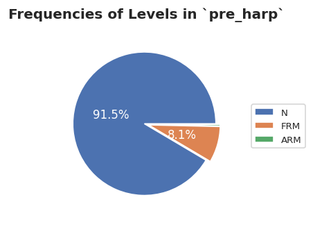

```python
# delete `harp_ind` from the list of categorical variables
# var_c_1.remove('harp_ind')

# change NA in `pre_harp` to `N`
df_covs['pre_harp'] = df_covs['pre_harp'].fillna('N')

# differentiate between ARM and FRM
df_covs['pre_harp'] = df_covs['pre_harp'].mask(df_covs['pre_harp'].str.startswith('A'), 'ARM')
df_covs['pre_harp'] = df_covs['pre_harp'].mask(df_covs['pre_harp'].str.startswith('F'), 'FRM')

# visualize the frequencies of `pre_harp`
plt.rcParams['figure.figsize'] = (3, 3)
tmp = df_covs['pre_harp'].value_counts()
plt.title('Frequencies of Levels in `pre_harp`', size=12, fontweight='bold', pad=10)
plt.pie(tmp, radius=0.95, explode=np.repeat(0.03, len(tmp)), autopct=show_autopct, pctdistance=0.48, textprops=dict(size=10, color='white'))
plt.legend(tmp.index, loc='lower center', prop={'size': 8}, bbox_to_anchor=(1.2, 0.35));
```

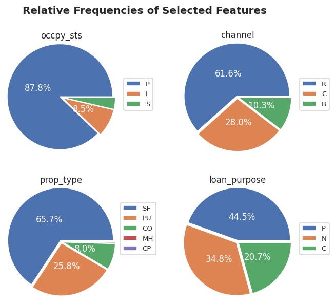

```python
# visualize the frequencies of `occpy_sts`, `channel`, `prop_type`, and `loan_purpose`
fig, axes = plt.subplots(2, 2, figsize=(3*2, 3*2))
fig.subplots_adjust(wspace=0.6, hspace=-0.1)
fig.suptitle('Relative Frequencies of Selected Features', fontweight ='bold', size=12)
fig.subplots_adjust(top=0.95)
tmp = [0, 1]*2
for i, var in enumerate(var_c_level[2][:4]):
    bi_counts = df_covs[var].value_counts()
    axes[i//2, tmp[i]].set_title(var, size=10, pad=5)
    axes[i//2, tmp[i]].pie(bi_counts, explode=np.repeat(0.03, len(bi_counts)), radius=1.2, autopct=show_autopct, pctdistance=0.45, textprops=dict(size=10, color='white'))
    axes[i//2, tmp[i]].legend(bi_counts.index, loc='lower center', prop={'size': 8}, bbox_to_anchor=(1.2, 0.35))
plt.show()
```

To make `seller_name` more informative, we decide to regroup its levels. For all banks (non-banks) whose total original UPB is no less than 1% of the total original UPB of all loans for a given calendar quarter, we label them as `BANK` (`NON-BANK`). For all the other sellers that do not satisfy the condition mentioned previously, we denote them as `OTHERS`, regardless of whether they are actually banks or non-banks. Similar to `seller_name`, `servicer_name` will be descretized into `BANK`, `NON-BANK`, and `OTHERS`.

```python
# discretize the seller
seller_bank = df_covs.loc[df_covs['seller_name'].str.contains('BANK'), 'seller_name'].unique()
seller_nonbank = np.setdiff1d(df_covs['seller_name'].unique(), np.append(seller_bank, 'Other sellers'))
cond_list = [
        (np.isin(df_covs['seller_name'], seller_bank)),
        (np.isin(df_covs['seller_name'], seller_nonbank)),
        (df_covs['seller_name'] == 'Other sellers')
]
choice_list = np.array(['BANK', 'NON_BANK', 'OTHERS'])
df_covs['seller_name'] = np.select(cond_list, choice_list)

# discretize the seller
servicer_bank = df_covs.loc[df_covs['servicer_name'].str.contains('BANK'), 'servicer_name'].unique()
servicer_nonbank = np.setdiff1d(df_covs['servicer_name'].unique(), np.append(servicer_bank, 'Other servicers'))
cond_list = [
        (np.isin(df_covs['servicer_name'], servicer_bank)),
        (np.isin(df_covs['servicer_name'], servicer_nonbank)),
        (df_covs['servicer_name'] == 'Other servicers')
]
choice_list = np.array(['BANK', 'NON_BANK', 'OTHERS'])
df_covs['servicer_name'] = np.select(cond_list, choice_list)
```

We have three geographical features in the data. The feature `cd_msa` indicates the Metropolitan Statistical Area (MSA) or Metropolitan Division (MD) where the mortgaged property is. The postal code of the location of the mortgaged property is included in `zipcode`. Lastly, `st` represents the state or territory in which the mortgage is located.

```python
# check the number of missing values
var_c_2 = np.array(['cd_msa', 'zipcode', 'st'])
pd.DataFrame({'%NA':df_covs[var_c_2].isna().sum()/df_covs.shape[0]*100, '#levels':df_covs[var_c_2].nunique()})
```

|  | %NA | #levels |
| --- | --- | --- |
| cd_msa | 11.230015 | 426 |
| zipcode | 0.000000 | 869 |
| st | 0.000000 | 54 |

```python
# replace NA in `cd_msa` with 0
df_covs['cd_msa'] = df_covs['cd_msa'].fillna(0)
```

We also exclude `zipcode` from our models for two reasons. Firstly, `zipcode` may repeat the information already included in `cd_msa`. Secondly, a valid USA postal code should consist of five digits. According to the output, ca. 7.619% of the entries in `zipcode` do not satisfy this requirement.

```python
# check the number of invalid ZIP code in the dataset
print(f'The proportion of invalid ZIP code is {(df_covs["zipcode"] < 10000).sum()/df_covs.shape[0]*100:.3f}%.')
```

```
The proportion of invalid ZIP code is 7.619%.
```

```python
# create a variable for all categorical features that will be used
var_c = np.append(var_c_1, 'cd_msa')
```

Notice that in the benchmark model, we only include numerical variables so that we can avoid the non-convergence problem caused by the one-hot-encoding for categorical features with high cardinality. In the SDDR model, we still apply one-hot-encoding to categorical covariates with only two levels, but we will employ a technique called "embedding" to deal with the "curse of dimensionality". More details follow in Section 4.2.

### 2.3 Merged Data

Now we merge the dataframes for monthly performance data and origination data. We generate a heatmap of Pearson correlation among numerical features because it can afford us a first impression of the relationship among numerical features and helps us decide which features should we drop to avoid the potential multicollinearity.

```
The number of cases that have invalid transition: 55.
```

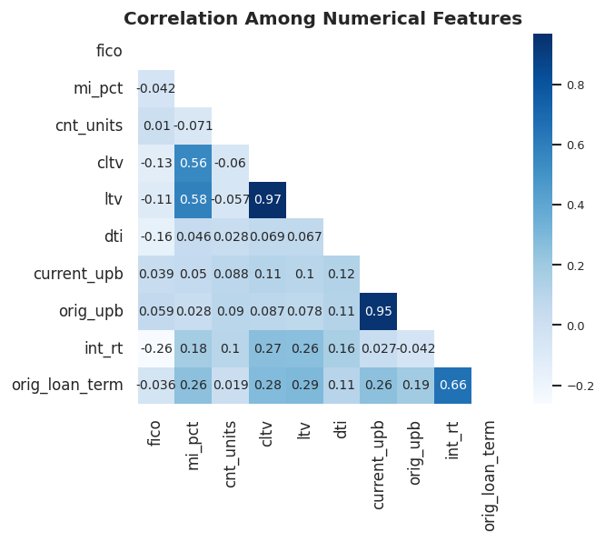

```python
# calculate the number cases that have invalid transition
tmp = df_trans.groupby('id_loan')['delq_sts'].diff()
print(f'The number of cases that have invalid transition: {(tmp > 1).sum()}.')

# select the cases with valid transition
df_trans = df_trans[tmp <= 1]

# merge `df_trans` with `df_covs`
df_merge = pd.merge(
    df_trans.drop(columns='period'), df_covs[np.hstack(('id_loan', np.setdiff1d(var_n, df_trans.columns), var_c)).ravel()], on='id_loan'
)

# check the correlation between numeric variables
corr_n = df_merge[var_n].corr()
mask = np.zeros_like(corr_n)
mask[np.triu_indices_from(mask)] = True
with sns.axes_style('white'):
    f, ax = plt.subplots(figsize=(4*1.5, 3*1.5))
    sns.set(font_scale=0.7)
    plt.xticks(size=10); plt.yticks(size=10)
    sns.heatmap(corr_n, mask=mask, square=True, annot=True, cmap='Blues')
ax.set_title('Correlation Among Numerical Features', fontweight='bold', fontsize=12)
plt.show()
```

As we expected, there is a strong correlation between `ltv` and `cltv`. Since `cltv` already incorporates the information of `ltv`, we will drop `ltv` from our models. The correlation between the original UPB (`orig_upb`) and the current UPB (`current_upb`) is also more than 0.9 and therefore one of them can be included in our models. We choose `current_upb` because it, like `cltv`, contains more information that we can use. The feature `mi_pct` has a modestly high correlation with `cltv` and the feature `orig_loan_term` is relatively strongly correlated with `int_rt`. Because we do not know which features should be excluded from the models, we keep all these variables and use data-driven methods, such as penalized logistic regression, to pursue feature selection.

```python
# drop some highly correlated variables
var_n = np.delete(var_n, np.isin(var_n, ['orig_upb', 'ltv']))
```

Because the benchmark model and the SDDR model are based on the marginal Bernoulli processes linked with the six events, we divide the whole dataset into six parts. We reserve 20% of the total observations for testing and use the remaining data to build and validate the model. To preserve the proportion of each class in the target, we use `StratifiedShuffleSplit` to generate stratified randomized folds.

```python
# split the data into training and test sets according to events
dfs_train = {event: None for event in events}
dfs_test = {event: None for event in events}
splitter = StratifiedShuffleSplit(n_splits=1, test_size=0.2, random_state=2022)
for event in events:
    k = int(event[-2])
    subset = pd.concat((df_merge[(df_merge['delq_sts'] == k) & (df_merge[events].sum(axis=1) == 0)], df_merge[df_merge[event] == 1])).sort_index()
    train_idx, test_idx = next(splitter.split(subset.drop(columns=events), subset[event]))
    dfs_train[event], dfs_test[event] = subset.iloc[train_idx], subset.iloc[test_idx]
```

After splitting the data into the training set(s) and the test set(s), we replace the missing value in `fico`, `cltv`, and `dti` with their median in the corresponding training sets. We also standardize all the numerical variables so that they have to same chance to be penalized in the logistic regression model (i.e., our benchmark model).

```python
# replace NAs in `fico`, `cltv`, and `dti` with corresponding median in the training set
train_median = {}
for event in events:
    train_median[event] = np.nanmedian(dfs_train[event][['fico', 'cltv', 'dti']], axis=0)
    dfs_train[event] = dfs_train[event].fillna(
        value={'fico': train_median[event][0], 'cltv': train_median[event][1], 'dti':train_median[event][2]}
    )

# deepcopy the list for 6 training sets
dfs_train_s = deepcopy(dfs_train)

# initiate a list for `ColumnTransformer`
ct_dict = {}

# standardize the numeric variables in the training sets
for event in events:
    ct_dict[event] = ColumnTransformer([('sc', StandardScaler(), var_n)])
    dfs_train_s[event][var_n] = ct_dict[event].fit_transform(dfs_train[event]).copy()
```

## 3. Methodologies

### 3.1 Benchmark Model

Following Djeundje & Crook (2018), we construct our benchmark (and also the SDDR model ) on the marginal Bernoulli processes associated with the predefined transition types. We define $\mathcal{S}$ as the set of all possible pairs of transition of states (i.e., $\mathcal{S} = \{(h, j) \mid h, j \in \{0, \ldots, 3\}\}$) and the individual random process for account $i (i \in {1, \ldots, n})$ as $$ Y_{ihj}(t) = \begin{cases} 1 & \text{if $i$ transitions from state $h$ at time $t-1$ to state $j$ at time $t$}\\ 0 & \text{if $i$ stays at state $h$ from time $t-1$ to $t$}\\ \end{cases}. $$

Under the assumption that account $i$ can only reach a specific state $j$ at time $t$, the non-competing probability $q_{ihj}(t)$ can be defined as $$ q_{ihj}(t) = \mathbf{P}(Y_{ihj}(t) = 1) = 1 - \mathbf{P}(Y_{ihj}(t) = 0). $$ We specify the non-competing probability as $$ q_{ihj}(t) = \mathbf{F}\left(\alpha_{hj}(t) + \mathbf{\beta}_{hj}^{T} \mathbf{X}_{ihj}(t)\right) \tag{1}, $$ where $\mathbf{F}$ stands for the logit link, $\alpha_{hj}$ is the baseline function for transition from state $h$ to state $j$, $\mathbf{\beta}_{hj}$ represents the vector of unknown coefficients, and $\mathbf{X}_{ihj}(t))$ is the vector of features of account $i$. Note that $\mathbf{X}_{ihj}(t)$ can be time-variant or -invariant. The likelihood function of $\mathbf{Y} = \{Y_{ihj} \mid (h,j) \in \mathcal{S}, i \in \{1, \ldots, n\}\}$ can be written as $$ L(\mathbf{\beta}, \mathbf{\alpha})= \prod_{(h,j)\in \mathcal{S}} \prod_{t} \prod_{i\in \mathcal{R}_{hj}(t)} \left[q_{ihj}(t)\right]^{y_{ihj}(t)}\left[1-q_{ihj}(t)\right]^{1-y_{ihj}(t)}, $$ where $\mathbf{\beta}$ and $\mathbf{\alpha}$ are the joint vector of $\mathbf{\beta}_{hj}$ and $\mathbf{\alpha}_{hj}$, respectively, and $\mathcal{R}_{hj}(t)$ is the risk set that includes all observations that transition from state $h$ to state $j$ at $t$.

We model the baseline function $\alpha_{hj}(t)$ with B-splines in the benchmark, i.e., $$ \alpha_{hj}(t) = \sum_{r=1}^{c} a_{hj, r} B_r(t),$$ where $B_r(t)$ is the basis function at time point $t$ and $a_{hj, r}$ is the corresponding coefficient need to be estimated. According to Djeundje & Crook (2018), using B-splines to model $\alpha_{hj}(t)$ enjoys two advantages. Firstly, B-splines are more flexible to capture the characteristics of time because they are non-parametric. Secondly, B-splines have compact supports so that they have better numerical properties than other types of splines.

By nature of its definition, the non-competing probabilities suffer from its underlying assumption that each transition type is modeled in isolation. In order to apply the models to data in reality, we need to calculate the competing probabilities, i.e., the probability that an account $i$ transitions from state $h$ at time $t-1$ to any permissible state $j$ at time $t$. Assuming the occurrence of non-competitive transitions is uniformly distributed over each month, we can compute the competing probabilities with $$ \begin{cases} \tilde{q}_{i01}(t) = q_{i01}(t) \\ \tilde{q}_{i10}(t) = q_{i10}(t) \left[1-\frac{1}{2}q_{i12}(t)\right] \\ \tilde{q}_{i12}(t) = q_{i12}(t) \left[1-\frac{1}{2}q_{i10}(t)\right] \\ \tilde{q}_{i20}(t) = q_{i20}(t) \left[1-\frac{1}{2}\left(q_{i21}(t)+q_{i23}(t)\right) + \frac{1}{3}q_{i21}(t)q_{i23}(t)\right] \\ \tilde{q}_{i21}(t) = q_{i21}(t) \left[1-\frac{1}{2}\left(q_{i20}(t)+q_{i23}(t)\right) + \frac{1}{3}q_{i20}(t)q_{i23}(t)\right] \\ \tilde{q}_{i23}(t) = q_{i23}(t) \left[1-\frac{1}{2}\left(q_{i20}(t)+q_{i21}(t)\right) + \frac{1}{3}q_{i20}(t)q_{i21}(t)\right]\\ \end{cases} \tag{2}. $$ The justification of Equation (2) can be found for example in Luptakova and Bilikova (2014) and Dickson et al. (2009).

Based on the competing probabilities, the non-homogenous predicted transition probability matrices can be constructed as follows: $$ \mathbf{P}_i(t) = \begin{bmatrix} 1-\tilde{q}_{i01}(t) & \tilde{q}_{i01}(t) & 0 & 0 \\ \tilde{q}_{i10}(t) & 1-\tilde{q}_{i10}(t)-\tilde{q}_{i12}(t) & \tilde{q}_{i12}(t) & 0 \\ \tilde{q}_{i20}(t) & \tilde{q}_{i21}(t) & 1-\tilde{q}_{i20}(t)-\tilde{q}_{i21}(t)-\tilde{q}_{i23}(t) & \tilde{q}_{i23}(t) \\ 0 & 0 & 0 & 1 \tag{3} \end{bmatrix}. $$ Now we can also calculate the probability that one account $i$ moves from state $\delta_i(t_1)$ at time $t_1$ to state $j \; (j \in \{0, \ldots, 3\})$ at time $t_2$ through $$ \mathbf{\mu}_i(t_2) = \begin{bmatrix} \mathbb{1}_{\delta_i(t_1) = 0} & \mathbb{1}_{\delta_i(t_1) = 1} & \mathbb{1}_{\delta_i(t_1) = 2} & \mathbb{1}_{\delta_i(t_1) = 3} \end{bmatrix} \tilde{\mathbf{P}}_i(t_1, t_2) \tag{4}, $$ where $\mathbb{1}$ is the indicator function and $$ \tilde{\mathbf{P}}_i(t_1, t_2) = \prod_{t=t_1+1}^{t_2} \tilde{\mathbf{P}}_i(t)$$ is the cumulative transition probability matrix.

### 3.2 Semi-Structured Deep Distributional Regression (SDDR)

#### 3.2.1 Orthogonality and interpretability

Semi-Structured Deep Distributional Regression (SDDR) combines deep neural networks and structured additive distributional regression (SADR; Rigby & Stasinopoulos, 2005), which in turn combines distributional regression and generalized additive model. The probability parameter $p$ of a Bernoulli random variable $\mathcal{Bern}(p)$ can be modeled by a linear part $\beta^\top\mathbf{x}$, a non-linear part $\sum_{j}{f_j(z_j)}$, and a neural network part $\sum_{m}{d_m(\mathbf{u}_m)}$.

$$ p = sigmoid\left(\beta^\top\mathbf{x} + \sum_{j}{f_j(z_j)} + \sum_{m}{d_m(\mathbf{u}_m)} \right) $$

The three parts are framed by a network architecture shown below. The linear part forms a single-unit layer with inputs as features multiplied by fitted coefficients. The non-linear part forms a single-unit layer as well, with inputs as basis functions multiplied by fitted spline coefficients. The neural network part is defined by users and has its outputs of the second last layer sent to an orthogonalization unit where the outputs undergo a matrix multiplication with the orthogonal complement of the space spanned by the outputs of the linear and non-linear parts. Therefore, the inputs of the last layer of the network are orthogonal to the linear and non-linear parts, leading to the retained interpretability of the latter.

[figure not shown]

SDDR architecture, extracted from Rügamer et al. (2020)

#### 3.2.2 SDDR model setup

As stated in the previous section, the transition events $Y_{ihj}(t)$ are assumed to be marginal Bernoulli processes, and the non-competing transition probabilities $q_{ihj}(t)$ are modeled by the baseline function $\alpha_{hj}(t)$, the linear combination of covariates and their coefficients $\mathbf{\beta}_{hj}^\top\mathbf{X}_{ihj}(t)$, and the sigmoid link function $\mathbf{F}$ as shown in Equation (1). Using the theoretical structure and implementation provided by the Semi-Structured Deep Distributional Regression Model (SDDR Model) and its Python package (Rügamer et al., 2020; Rügamer et al., 2021), we extend the logistic models with several deep neural networks (DNN) $d_m(\mathbf{Z}_{ihjm}(t))$ with $\mathcal{X}$ being the entire feature space shown in Equation (5).

$$ q_{ihj}(t) = \mathbf{F}\left(\alpha_{hj}(t) + \mathbf{\beta}_{hj}^{T} \mathbf{X}_{ihj}(t) + \sum_{m=1}^{M}{d_m(\mathbf{Z}_{ihjm}(t))} \right), \quad \mathbf{Z}_{ihjm}(t) \subseteq \mathcal{X}, m \in \mathbb{N} \tag{5} $$

The linear features $\mathbf{X}_{ihj}(t)$ in the SDDR models include the same numerical features as those in the benchmark logistic models and in addition, the binary categorical features after they are One-Hot-Encoded. The baseline function $\alpha_{hj}(t)$ is still B-splines with the summation of basis functions of the age of loan account `time` and their respective fitted coefficients. However, due to implementation restrictions in the PySDDR package, the distances between knots could not be determined by the quantiles of the distribution of `time`, but could only be equal (e.g., if there are four internal knots and the range of `time` is from 1 to 100, they are at `time` 20, 40, 60, and 80). Unlike the benchmark, the degrees of the piecewise polynomials and the number of knots here are tuned by grid-search cross-validation. The types of available polynomials and the number of knots will be discussed in Section 4. Applications. A smoothing penalty to the splines is applied and also determined by cross-validation.

The neural network architecture is designed to be feed-forward and with fully connected layers. The network part of the model could be further split into three parts. First, all of the numerical and binary features are fed into one network with matching input neurons. Second, based on the findings from the benchmark models, the age of loan `time` is the major contributor to the prediction of transition probabilities. Hence `time` is the single feature in the second network. Third, categorical features consisting of more than two unique levels are first fed into an embedding layer, and then go through the same number of hidden layers as the former networks. Instead of transforming categorical features into $\#levels - 1$ dummy features, which are doomed to be sparse, embedding each categorical feature in a shorter vector could greatly reduce the dimensions of the inputs and protect the models from overfitting the training data. The lengths of the embedded vectors are determined by a heuristic shown in Equation (6). Due to complications setting up the networks, each multi-category feature makes up a network, with the embedding layer, fully connected hidden layers, and the output layer.

$$ min\{50, \ \lfloor \text{number of unique levels} \ /\ 2 \rfloor \} \tag{6} $$

To summarize, there are one network for the numerical and binary features, one for `time`, and eight networks, each for one multi-category feature. The number of hidden layers and the size of each layer relative to the input size are the same across the ten networks, and they are tuned by randomized-search cross-validation along with the dropout rate for the neurons. These hyper-parameters will be addressed in detail in Section 4. Applications. The networks, together with the linear predictors and the splines, predict the transition probabilities between delinquency states, as shown in Equation(5). $M$ here is thus $10$.

#### 3.2.3 Loss function and optimization

Negative log-likelihood is computed as the loss function to train the model. According to Rügamer and colleagues (2020), convergence difficulties occurred when the non-linear parts were not penalized. Thus, a smoothing penalty was added to the loss function as shown in Equation (7). The penalty consists of $\lambda$, a tunable smoothing parameter, and the quadratic form of the spline coefficients $\mathbf{w}$ and some penalty matrix $\mathbf{S}$ (see Wood, 2017).

$$ -log p_\mathcal{BER} ( Y_{ihj}(t) | \hat{q}_{ihj}(t) ) + \lambda \mathbf{w}^\top \mathbf{S} \mathbf{w} \tag{7} $$

This loss function is minimized by the algorithm `RMSProp` using PyTorch's built-in module (Graves, 2013). Since SDDR does not support a flexible learning-rate scheduler, the learning rate and momentum for `RMSProp` are tuned by randomized-search cross-validation as well.

#### 3.2.4 Expected results

One of the reasons we choose SDDR models as our extension from benchmark logistics is to keep the linear and non-linear effects interpretable. As introduced earlier, SDDR models impose orthogonality between the linear, non-linear, and neural network parts, and prioritize sequentially for attribution of prediction the linear predictors, the splines, then the networks. Therefore, we expect the linear predictors show similar effects on the transition probabilities as the benchmark counterparts. The addition of binary features could change some but not all of the coefficients and relative importance of the features. As for non-linear B-splines, similar curves mapping the relationships between the age of loan accounts and the probabilities are expected. The more complex relationship between the two learned by the neural network of `time` is also expected. Finally, we expect an improved area under the ROC curve for each of the models fitted to different transition events. With the predicted non-competing transition probabilities, competing probabilities are computed and the delinquency state in the next month is predicted determined. The overall accuracy of the predicted state across models is expected to increase as well.

## 4. Applications

### 4.1 Benchmark Model

To make the shape of B-splines to be less likely affected by the choice of the knots, we specify five knots according to the quantiles of the variable `time`. We set the polynomial degree of the spline basis to be three because cubic polynomial has the lowest degree to support an inflection among all the other polynomials. In total, seven splines are created. We save the results of fitting with the training data in a dictionary named `add_spline_dict` so that we can reuse the results later for the test set. The minimum or maximum of `time` in the training set is used for constant extrapolation.

```python
# specify the number of knots and degrees
n_knots = 5
degree = 3

# create a list for the name of created variables
time_splines_names = ['t_s_'+ str(i) for i in range(n_knots+degree-1)]

# save instances for `SplineTransformer` and add splines to each training set
add_spline_dict = {}
for event in events:
    add_spline_dict[event] = SplineTransformer(n_knots=n_knots, degree=degree, knots='quantile')
    df_tmp = pd.DataFrame(
        add_spline_dict[event].fit_transform(np.array(dfs_train_s[event]['time']).reshape(-1, 1)),
        index=dfs_train_s[event].index, columns=time_splines_names
    )
    dfs_train_s[event] = pd.concat((dfs_train_s[event], df_tmp), axis=1)
```

Whether the class imbalance exists in the dataset can exert great influence on which metric we decide to use during the cross-validation of our classification model. As shown in the table, we have a large bias toward the majority class in data for `event_01`: for every one observation that is one month in arrears, there are roughly 263 observations that stay up-to-date. We still have class imbalance in data for `event_12`, `event_20`, and `event_21`; nevertheless, the imbalance is not as severe as that in data for `event_01`. In contrast to other events, `event_10` and `event_23` have $Y_{ihj}(t)=1$ as the majority class.

```python
# extract features and target
X_train_bm, y_train_bm = {}, {}
for event in events:
    X_train_bm[event] = dfs_train_s[event][var_n.tolist()+time_splines_names]
    y_train_bm[event] = dfs_train_s[event][event]

# check the ratio of 1 to 0 in each dataframe & calculate the empirical cut-off in the training set
df_ratio = np.empty(18)
for i, event in enumerate(events):
    tmp = y_train_bm[event].value_counts().sort_index()
    df_ratio[3*i:3*(i+1):1] = tmp[0], tmp[1], tmp[0]/tmp[1]
pd.DataFrame(df_ratio.reshape(-1, 3), columns=['0', '1', 'ratio'], index=events)
```

|  | 0 | 1 | ratio |
| --- | --- | --- | --- |
| event_01 | 1909578.0 | 7262.0 | 262.954833 |
| event_10 | 3641.0 | 5402.0 | 0.674010 |
| event_12 | 3641.0 | 2163.0 | 1.683310 |
| event_20 | 648.0 | 480.0 | 1.350000 |
| event_21 | 648.0 | 264.0 | 2.454545 |
| event_23 | 648.0 | 1352.0 | 0.479290 |

Because of the large number of observations for `event_01`, we train the benchmark model for `event_01` individually. We propose to implement weighted logistic regression with L1-penalty for the sake of feature selection and the alleviation of the problem of class imbalance. The weight is inversely proportional to class frequency in the data for `event_01`. To deal with the highly imbalanced data, we also choose the area under the receiver operating characteristic (ROC) curve (AUC) as the metric to evaluate the performance of models during the cross-validation. To facilitate the cross-validation, we use the randomized search on hyper-parameters for the benchmark model. We assume that the inverse of the regularization strength is uniformly distributed on [1, 21]. Since the training for `event_01` is extremely time-consuming, we saved the model after the training and load it for further analysis. The original codes for training are commented out.

```python
# # set the dictionary of parameters
# hyper_bm_1 = dict(C=uniform(loc=1, scale=20))
#
# # initiate logistic regression
# lr_1 = LogisticRegression(class_weight='balanced', penalty='l1', solver='saga', random_state=2022, max_iter=350, tol=1e-4, warm_start=True)
#
# # initiate randomized search for "event_01"
# rs_bm = {'event_01': RandomizedSearchCV(lr_1, hyper_bm_1, random_state=2022, scoring='roc_auc', cv=10)}
#
# # fit the training data
# warnings.simplefilter('ignore', category=ConvergenceWarning)
# rs_bm['event_01'].fit(X_train_bm['event_01'], y_train_bm['event_01'])
```

The tuning of hyper-parameters in models for other events is similar, except that we also allow the logistic regression to be unweighted and the maximal number of iterations to vary.

```python
# # set the dictionary of parameters
# hyper_bm_2 = dict(C=uniform(loc=1, scale=20), class_weight=[None, 'balanced'], max_iter=uniform(loc=100, scale=300))
#
# # initiate logistic regression
# lr_2 = LogisticRegression(random_state=2022, penalty='l1', solver='saga', warm_start=True)
#
# # create placeholder
# for event in events[1:]:
#     rs_bm[event] = RandomizedSearchCV(lr_2, hyper_bm_2, random_state=2022, scoring='roc_auc', cv=10)
#
# # fit the training data
# warnings.simplefilter('ignore', category=ConvergenceWarning)
# for event in events[1:]:
#     rs_bm[event].fit(X_train_bm[event], y_train_bm[event])
```

```python
# # save the best parameters
# bm_opt_params = {}
# for event in events:
#     bm_opt_params[event] = rs_bm[event].best_params_
#
# # fit the model with optimal parameters, extract the coefficients for basis functions
# bm_opt_model= {}
# bm_opt_model['event_01'] = LogisticRegression(
#     class_weight='balanced', penalty='l1', solver='saga', random_state=2022, max_iter=350,
#     tol=1e-4, C=bm_opt_params['event_01']['C'], warm_start=True
# ).fit(X_train_bm['event_01'], y_train_bm['event_01'])
# for event in events[1:]:
#     bm_opt_model[event] = LogisticRegression(
#         class_weight=bm_opt_params[event]['class_weight'], penalty='l1', solver='saga', random_state=2022,
#         max_iter=bm_opt_params[event]['max_iter'], C=bm_opt_params[event]['C'], warm_start=True
#     ).fit(X_train_bm[event], y_train_bm[event])
#
# # save models
# file_names = ['bm_'+event+'.sav' for event in events]
# for i, event in enumerate(events):
#     joblib.dump(bm_opt_model[event], 'bm_outputs/'+file_names[i])
```

```python
# load the trained model and calculate the coefficients/intercepts
bm_opt_model = {}
coefs_bm, intcp_bm = {}, {}
for event in events:
    bm_opt_model[event] = joblib.load('bm_outputs/bm_'+event+'.sav')
    coefs_bm[event] = np.array(bm_opt_model[event].coef_)
    intcp_bm[event] = np.array(bm_opt_model[event].intercept_)
```

The hyper-parameters resulting from the randomized search are shown below. Consistent with our previous analysis, all events except `event_10` and `event_23` need weighted logistic regression. Compared with models for other events, models for`event_20` and `event_21` need stronger regularization.

```python
# check the hyper-parameters
bm_h_params = []
for event in events:
    tmp = bm_opt_model[event].get_params()
    bm_h_params.append([tmp['class_weight'], tmp['C'], tmp['max_iter']])
pd.DataFrame(bm_h_params, index=events, columns=['class_weight', 'C', 'max_iter'])
```

|  | class_weight | C | max_iter |
| --- | --- | --- | --- |
| event_01 | balanced | 18.953145 | 350.000000 |
| event_10 | None | 17.627068 | 388.783084 |
| event_12 | balanced | 15.884124 | 356.283098 |
| event_20 | balanced | 1.187172 | 253.962273 |
| event_21 | balanced | 1.187172 | 253.962273 |
| event_23 | None | 10.896753 | 194.082030 |

Since all the numerical features are standardized, the estimation of coefficients can be deemed as feature importance. As shown in the figure, the estimated coefficients hardly deviate from zero except those for base functions of B-spline (i.e. `t_s_*`). This estimation is in accordance with the idea that time-dependent probabilities are largely driven by the baseline intensities (Djeundje & Crook, 2018). From the figure we can see that the estimated coefficients for the "boundary" base functions `t_s_0` and `t_s_6` have an eminently noticeable large magnitude.

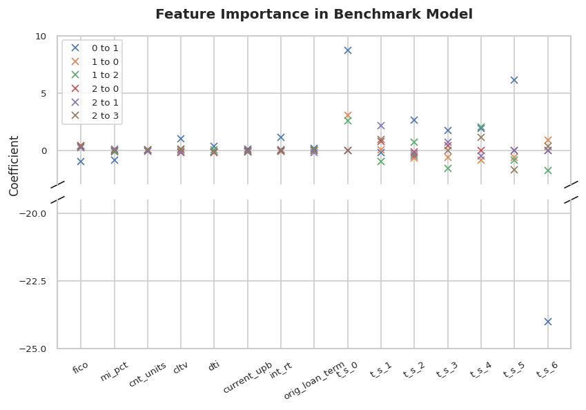

```python
# generate plot for feature importance
labels = ['0 to 1', '1 to 0', '1 to 2', '2 to 0', '2 to 1', '2 to 3']
plt.rcParams['figure.figsize'] = (8, 5)
plt.rcParams['figure.dpi'] = 120
fig, (ax1, ax2) = plt.subplots(2, 1, sharex='col')
fig.subplots_adjust(hspace=0.1) # set distance between two subplots
fig.text(0.06, 0.5, 'Coefficient', ha='center', rotation='vertical', fontsize=10)
ax1.set_title('Feature Importance in Benchmark Model', fontweight='bold', fontsize=12, pad=15)
ax1.tick_params(axis='x', which='both', bottom=False, labelbottom=False) # remove the ticks in x-axis
ax1.tick_params(axis='y', labelsize=8)
ax2.tick_params(axis='y', labelsize=8)
ax2.set_xticks(np.arange(15), var_n.tolist()+time_splines_names, rotation=30, size=8)
ax1.set_yticks([0, 5, 10])
ax2.set_yticks([-25, -22.5, -20])
ax1.set_ylim(-3, 10)
ax2.set_ylim(-25, -19.5)
ax1.spines.bottom.set_visible(False) # remove the bottom spines of the upper figure
ax2.spines.top.set_visible(False) # remove the upper spines of the lower figure
for i, event in enumerate(events):
    ax1.plot(np.arange(15), coefs_bm[event].ravel(), 'x', label=labels[i])
    ax1.legend(loc='upper left', fontsize=8)
    ax2.plot(np.arange(15), coefs_bm[event].ravel(), 'x', label=labels[i])
kwargs = dict(marker=[(-1, -0.5), (1, 0.5)], markersize=12, linestyle='none', color='k', mec='k', mew=1, clip_on=False)
ax1.plot([0, 1], [0, 0], transform=ax1.transAxes, **kwargs)
ax2.plot([0, 1], [1, 1], transform=ax2.transAxes, **kwargs)
plt.show()
```

Assuming that all numerical features are zero and all categorical features are in the reference group, we can calculate the baseline transition probabilities solely driven by the variable `time`. In other words, the hazard of occurrences of events is dependent before the actual occurrence of the event. The result of the calculation is presented in the following figure whose x-axis and y-axis represent the time and the baseline probability, respectively. As shown in the figure, the patterns of baseline transition probabilities vary conspicuously across different events and different time periods.

At the beginning of the repayment, the probability of moving toward the first state of delinquency is only slightly over 0.3. This estimation of probability is in line with the low empirical frequency of observations that go from state 0 to state 1 in the dataset. Although the transition probability of `event_01` fluctuates as times goes by, the average trend is upward. After reaching the peak at ca. 60 months, the probability of advancing to state 1 from state 0 plummets.

The probability of transition from state 1 to state 2 vacillates. Before 50 months, the probability of advancing to state 2 from state 1 is always lower than that of recovering from state 1 to state 0. After 50 months, the lines representing the probabilities of these two events intertwine. The probability of recovering to state 0 increases after ca. 53 months but never returns to the highest value that can be attained at the start of repayment.

If an observation is already in state 2, then the probability of becoming up-to-date is always lower than that of entering the default. More precisely, the baseline transition probability of `event_20` oscillates around 0.5. The probability of moving from state 2 to state 1 becomes lower than that of transitioning from state 2 to state 0 after ca. 2/3 of the lifetime of the loan. The baseline probability of entering default, given that a case is already two months in arrears, is almost always larger than 0.5 except at the end of the mortgage loan.

One last thing worthy to notice in the figure is that the probabilities of advancing to the next state always reduce after 60 months while the probabilities of recovering to a lower state at least do not decrease.

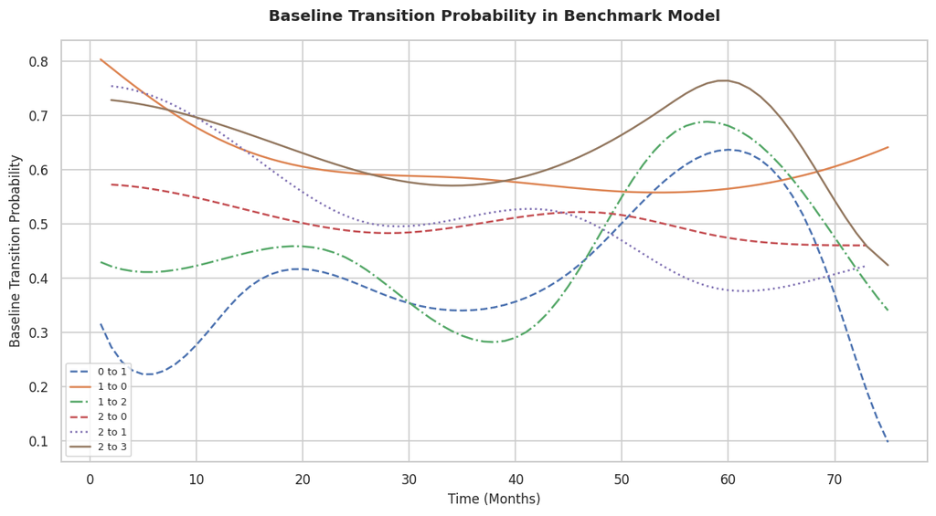

```python
# calculate the baseline probability of each event
dfs_spline_bm = {}
for event in events:
    eta = np.matmul(X_train_bm[event].iloc[:, -(n_knots+2):].to_numpy(), coefs_bm[event][:, -(n_knots+2):].T).ravel()+intcp_bm[event]
    dfs_spline_bm[event] = pd.DataFrame(
        {
            'time': dfs_train_s[event]['time'],
            'nc_proba': 1/(1+np.exp(-eta))
        }
    )
    dfs_spline_bm[event].sort_values(by='time', inplace=True)

# create plots for baseline transition
markers = ['--', '-', '-.', '--', ':', '-']
plt.rcParams['figure.figsize'] = (12, 6)
plt.rcParams['figure.dpi'] = 120
fig, ax = plt.subplots()
plt.title('Baseline Transition Probability in Benchmark Model', fontweight='bold', fontsize=12, pad=15)
plt.xticks(size=10);plt.yticks(size=10)
plt.xlabel('Time (Months)', fontsize=10)
plt.ylabel('Baseline Transition Probability', fontsize=10)
for i, event in enumerate(events):
    ax.plot(dfs_spline_bm[event]['time'], dfs_spline_bm[event]['nc_proba'], markers[i], label=labels[i])
    ax.legend(loc='lower left')
```

Now we would like to evaluate the benchmark model first in six test sets individually. As illustrated by the ROCs, the performance of the benchmark model is relatively unsatisfactory. The model for `event_20` achieves the highest AUC (0.712). The AUCs of models for `event_01` and `event_12` are also above 0.7, respectively. The performance of the model for `event_21` is just slightly better than a random guess.

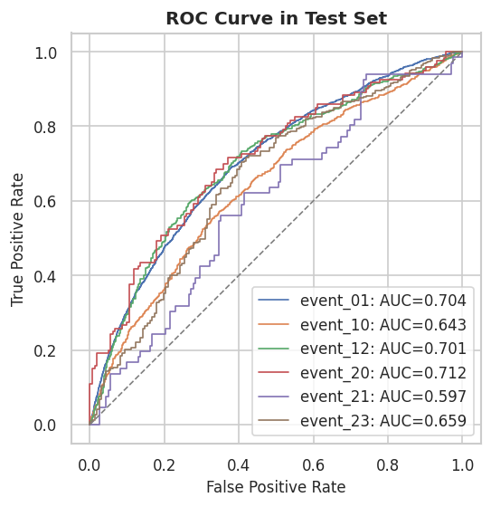

```python
# extract features and target in test set
bm_test_separate = {}
X_test_bm, y_test_bm = {}, {}
for event in events:
    bm_test_separate[event] = ApplyBMModel(
        df=dfs_test[event], scaler=ct_dict[event], var_to_standardize=var_n.tolist(),
        spline_transformer=add_spline_dict[event], splines_names=time_splines_names,
        value_to_fillna=train_median[event], model_coefs=coefs_bm[event], model_intercept=intcp_bm[event]
    )
    X_test_bm[event] = bm_test_separate[event].get_processed_df()[var_n.tolist()+time_splines_names]
    y_test_bm[event] = dfs_test[event][event]

# calculate fpr, tpr, and auc
bm_fpr, bm_tpr, bm_auc = {}, {}, {}
for event in events:
    y_score = bm_opt_model[event].predict_proba(X_test_bm[event])[:, 1]
    bm_fpr[event], bm_tpr[event], _ = roc_curve(y_true=y_test_bm[event], y_score=y_score)
    bm_auc[event] = roc_auc_score(y_true=y_test_bm[event], y_score=y_score)

# visualize ROC
plt.rcParams['figure.figsize'] = (5, 5)
plt.rcParams['figure.dpi'] = 120
fig, ax = plt.subplots()
plt.title('ROC Curve in Test Set', fontweight='bold', fontsize=12)
plt.xticks(size=10); plt.yticks(size=10)
plt.xlabel('False Positive Rate', fontsize=10)
plt.ylabel('True Positive Rate', fontsize=10)
for event in events:
    ax.axis('equal')
    ax.set_aspect('equal', adjustable='box')
    ax.plot(bm_fpr[event], bm_tpr[event], linewidth=1, label=f'{event}: AUC={bm_auc[event]:.3f}')
    ax.legend(loc='lower right', fontsize=10)
plt.plot([0,1], [0,1], linewidth=1, color='gray', linestyle='--')
plt.show()
```

Next we want to apply each of the six logistic regression models to the merged test set and compute the non-competing probabilities.

```python
# merge test datasets and save indices of cases in test set according to previous states
df_test_merged = pd.concat(dfs_test.values()).drop_duplicates().sort_index()
subsets = ['event_0*', 'event_1*', 'event_2*']
idx_test_merged = {}
for subset in subsets:
    idx_test_merged[subset] = np.unique(np.concatenate([dfs_test[event].index for event in events if event[-2] == subset[-2]]))

# apply the benchmark models to `event_0*`, `event_1*`, and `event_2*` and calculate the non-competing probabilities
bm_test, bm_test_nc_proba = {}, {}
for event in events:
    bm_test[event] = ApplyBMModel(
        df_test_merged, scaler=ct_dict[event], var_to_standardize=var_n.tolist(),
        spline_transformer=add_spline_dict[event], splines_names=time_splines_names,
        value_to_fillna=train_median[event], model_coefs=coefs_bm[event], model_intercept=intcp_bm[event]
    )
    bm_test_nc_proba[event] = bm_test[event].get_non_competing_proba()

# calculate competing probabilities / transition probability matrix
bm_t_proba_mat = TransitionProbaMatrix(bm_test_nc_proba).get_transition_proba(length=df_test_merged.shape[0], index=df_test_merged.index)
```

Before we evaluate the performance of the benchmark models in the merged test set, we would like to present one of the applications of our models. With Equations (2) and (3), we can calculate the competing probabilities and the non-homogenous predicted transition probability matrix, respectively. Using Equation (4), we can predict which state an account would be in for a predefined time point. Since account `F15Q10000025` has consecutive observations from time 44 to time 48 in the test set, we would like to use it to demonstrate how to generate and interpret the (cumulative) transition probability matrix. For example, the predicted probability that `F15Q10000025` recovers from state 1 to state 0 at time 44 is around 0.591. Based on our benchmark models, we predict that `F15Q10000025` is in state 0 at time 48.

```python
# show the predicted transition probability matrix for account `F15Q10000025` at t=44
print(f'* Predicted transition probability matrix for loan `{df_test_merged.loc[44, "id_loan"]}` at time 44 is \n {np.round(bm_t_proba_mat.loc[44, :].to_numpy().reshape(4, 4), 3)}')

# calculate the probabilities of account `F15Q10000025` from t_1=44 to t_2=48
P_44_48 = np.matmul(
    np.matmul(bm_t_proba_mat.loc[45, :].to_numpy().reshape(4, 4), bm_t_proba_mat.loc[46, :].to_numpy().reshape(4, 4)),
    bm_t_proba_mat.loc[47, :].to_numpy().reshape(4, 4)
)
print(f'* Cumulative transition probability matrix from t1=44 to t2=48 is \n {np.round(P_44_48, 3)}')
print(f'* State at t1: {df_test_merged.loc[2, "delq_sts"]}')
print(f'* Predicted state at t2: {np.matmul([int(df_test_merged.loc[2, "delq_sts"] == i) for i in [0, 1, 2, 3]], P_44_48).argmax()}')
```

```
* Predicted transition probability matrix for loan `F15Q10000025` at time 44 is
 [[0.974 0.026 0.    0.   ]
 [0.591 0.173 0.236 0.   ]
 [0.351 0.283 0.018 0.348]
 [0.    0.    0.    1.   ]]
* Cumulative transition probability matrix from t1=44 to t2=48 is
 [[0.949 0.038 0.01  0.003]
 [0.802 0.054 0.035 0.109]
 [0.549 0.046 0.019 0.386]
 [0.    0.    0.    1.   ]]
* State at t1: 0
* Predicted state at t2: 0
```

The prediction accuracy of the benchmark model is not even across 60%; therefore, models other than the benchmark should be considered.

```python
# predict the class
bm_pred_dict = {}
for (i, subset) in zip([0, 4, 8], subsets):
    bm_pred_dict[subset] = bm_t_proba_mat.loc[idx_test_merged[subset], i:i+3].idxmax(axis=1) - i
bm_pred = pd.concat(bm_pred_dict.values())

# calculate the accuracy in the test set
print(f'The prediction accuracy of the benchmark model in test set is {sum((df_test_merged["delq_sts"] - bm_pred) == 0)/df_test_merged.shape[0]*100:.3f}%.')
```

```
The prediction accuracy of the benchmark model in test set is 59.556%.
```

### 4.2 Semi-Structured Deep Distributional Regression

#### 4.2.1 Recall SDDR model setup

Recall that we build six SDDR models for each of the transition event `event_01`, `event_10`, `event_12`, `event_20`, `event_21`, and `event_23`. The SDDR models predict the probabilities with three parts: linear, non-linear, and neural networks. The linear part includes all features that served as linear predictors in the benchmark models plus the binary categorical features `flag_fthb`, `cnt_borr`, `flag_sc`, and `program_ind`. The non-linear part fits `time` as B-splines as in the benchmark models, but the piecewise polynomial degrees, the number of knots, and the smoothing penalty are tuned by cross-validation. The neural network part contains ten networks: one for all numerical and binary features, one for `time` alone, and eight networks for each of `occpy_sts`, `channel`, `prop_type`, `loan_purpose`, `seller_name`, `servicer_name`, `pre_harp`, and `cd_msa`.

```python
df_covs[var_c].apply(lambda x: x.unique())
```

```
flag_fthb                                                   [N, Y]
occpy_sts                                                [P, S, I]
channel                                                  [R, C, B]
prop_type                                     [SF, PU, MH, CO, CP]
loan_purpose                                             [P, N, C]
cnt_borr                                           [two_more, one]
seller_name                               [OTHERS, BANK, NON_BANK]
servicer_name                             [BANK, OTHERS, NON_BANK]
flag_sc                                                     [N, Y]
pre_harp                                             [N, ARM, FRM]
program_ind                                                 [N, Y]
harp_ind                                                    [N, Y]
cd_msa           [0.0, 11460.0, 39340.0, 20260.0, 47664.0, 1486...
dtype: object
```

There are several necessary modifications to the training and test data to apply SDDR models to them. Firstly, the age of loan account `time` needs to be of type `float` as the inputs of the neural networks. Secondly, `GridSearchCV` and `RandomizedSearchCV` from `scikit-learn` require ground truths and covariates to be separately fed into the cross-validation pipeline, so changes to the data are made accordingly. Thirdly, as there is no easy way to implement class weights in SDDR as in logistic regression, minority classes when modeling `event_10`, `event_12`, `event_20`, `event_21`, and `event_23` are over-sampled by SMOTE (Chawla, Bowyer, Hall, & Kegelmeyer, 2002). To overcome the severe imbalance and facilitate fast training, the majority class `0` in `event_01` is randomly down-sampled to the matching size of the minority class `1`. Lastly, multi-category features are transformed into numbers representing the categories, e.g., if there are five categories, the transformed numerics will be 0, 1, 2, 3, and 4, each representing a category. The transformation prepares these features for embedding. The process of under-/over-sampling, along with standardization of numerical features, One-Hot-Encoding, and transforming multi-category features, is performed within the customized `SddrEstimator`.

```python
# useful local variables
previous_sts = ['event_0*', 'event_1*', 'event_2*']
output_dir = "SDDR_outputs/"
```

```python
# change time from int to float
for event in events:
    dfs_train[event]['time'] = dfs_train[event]['time'].astype('float')
    dfs_test[event]['time'] = dfs_test[event]['time'].astype('float')
```

```python
# prepare training and test sets compatible with cross-validation
train_y = {event: dfs_train[event][[event]] for event in events}
dfs_test_merged = {}
for sts in previous_sts:
    dfs_test_merged[sts] = pd.concat([dfs_test[event] for event in events if event[-2] == sts[-2]]).drop_duplicates()
test_y = {event: dfs_test_merged[f'event_{event[-2]}*'][[event]] for event in events}
```

#### 4.2.2 Hyper-parameter tuning

As mentioned in Section 3. Methodologies, there are three spline-related hyper-parameters to tune, namely, the degrees of piecewise polynomials `spline_degree`, the number of internal knots `spline_num_knots`, and the smoothing penalty parameter lambda `spline_lambda_df_diff`. The lambda is determined by the `spline_lambda_df_diff` plus the total degree of freedom of the splines. For example, if `spline_degree=3`, `spline_num_knots=4`, and `spline_lambda_df_diff=-1`, the piecewise polynomials are cubic, the total degree of freedom is seven, and lambda is six. Available polynomials are quadratic or cubic, the number of knots is between 1 and 4, and the lambda-df difference is from -2 to 2.

As for neural networks, the number of hidden layers `num_hidden_layers`, the relative sizes of the hidden layers, and the output layer `layer_size_factor` and `output_size_factor`, and the dropout rate `dropout_rate` are tuned. Specifically, the number of hidden layers ranges from 2 to 5 due to machine capacity restrictions. The size of the hidden layers is determined by the ceiling of `input_size * layer_size_factor`, and the size of the output layer is the ceiling of `input_size * layer_size_factor * output_size_factor`. Both size factors are randomly drawn from a uniform distribution of range `[1,2]`. The dropout rate is randomly selected from a log-uniform distribution of range `[0.001, 0.1]`.

The optimization hyper-parameters for the `RMSProp` algorithm are also tuned with cross-validation. The learning rate `learning_rate` is from a log-uniform distribution of range `[0.001, 0.1]`. And the momentum `momentum` is determined by `1 - loguniform([0.001, 0.1])`, i.e., it ranges log-uniformly from 0.9 to 0.999.

To lift the burden imposed by cross-validation and thanks to the orthogonality between the non-linear and neural network parts, hyper-parameters related to splines are first tuned with grid-search cross-validation and fixed network-related hyper-parameters. After getting the best splines for each of the six models, we tuned the neural network-related hyper-parameters with randomized-search cross-validation and 50 iterations for each transition event. The batch size is set to allow the full training subset corresponding to the transition events to be trained at once. The number of epochs is set as 1000 with an early termination criterion of 0.01% improvement rates of validation loss in every 100 epochs.

The following cells run the hyper-parameter tuning and are commented out here for reasons of machine capacity and the amount of time it takes to run. Cross-validation results and the models using the best hyper-parameters are saved for later analyses.

```python
# # hyper-parameter tuning: splines
# param_grid = {
#     'spline_degree': [2,3], 'spline_num_knots': [1,2,3,4], 'spline_lambda_df_diff': [-2,-1,0,1,2],
#     'num_hidden_layers': [2], 'layer_size_factor': [1], 'output_size_factor': [1],
#     'learning_rate': [1e-2], 'momentum': [1e-2], 'dropout_rate': [1e-2]
# }
# best_estimator_splines = {}
# cv_results_splines = {}
```

```python
# # tuning splines parameters for all transition events except `event_01`
# for event in events[1:]:
#     sts = f"{event[:-1]}*"
#     gs = GridSearchCV(SddrEstimator(output_dir=output_dir, epochs=1000, early_stop_epochs=100), param_grid, n_jobs=-1, refit=True)
#     gs.fit(X=dfs_train[event], y=train_y[event])
#     best_estimator_splines[event] = gs.best_estimator_
#     cv_results_splines[event] = pd.DataFrame(gs.cv_results_)[['param_spline_degree', 'param_spline_num_knots', 'param_spline_lambda_df_diff', 'param_num_hidden_layers', 'param_layer_size_factor', 'param_output_size_factor', 'param_learning_rate', 'param_momentum', 'param_dropout_rate', 'mean_test_score', 'std_test_score', 'rank_test_score']]
#     cv_results_splines[event].columns = ['degree', 'num_knots', 'lambda_df_diff', 'num_hidden_layers', 'layer_size_factor', 'output_size_factor', 'learning_rate', 'momentum', 'dropout_rate', 'mean_test_score', 'std_test_score', 'rank_test_score']
#     cv_results_splines[event] = cv_results_splines[event].sort_values(by='rank_test_score')
```

```python
# # save trained model
# # for event in events[1:]:
# #     joblib.dump(best_estimator_splines[event], f'SDDR_outputs/best_estimator_splines_{event}.sav')

# # formula objects cannot be pickled, save cv_results instead
# # save results of cross validation over spline parameters
# for event in events[1:]:
#     best_estimator_splines[event].sddr_.save(f"SDDR_outputs/best_estimator_splines_{event}.pth")
#     cv_results_splines[event].to_csv(f"SDDR_outputs/cv_results_splines_{event}.csv")
```

```python
# # hyper-parameter tuning: neural networks
# best_estimator_nn = {}
# cv_results_nn = {}
```

```python
# # tuning nn parameters for all transition events except `event_01`
# for event in events[1:]:
#     param_dist = {
#         'spline_degree': [cv_results_splines[event]['degree'].iloc[0]],
#         'spline_num_knots': [cv_results_splines[event]['num_knots'].iloc[0]],
#         'spline_lambda_df_diff': [cv_results_splines[event]['lambda_df_diff'].iloc[0]],
#         'num_hidden_layers': [2,3,4,5], 'layer_size_factor': uniform(1,1), 'output_size_factor': uniform(1,1),
#         'learning_rate': loguniform(1e-3, 1e-1), 'momentum': loguniform(1e-3, 1e-1), 'dropout_rate': loguniform(1e-3, 1e-1)
#     }
#     sts = f"{event[:-1]}*"
#     rs = RandomizedSearchCV(SddrEstimator(output_dir=output_dir, epochs=1000, early_stop_epochs=100), param_dist, n_iter=50, n_jobs=-1, refit=True, random_state=2022)
#     rs.fit(X=dfs_train[event], y=train_y[event])
#     best_estimator_nn[event] = rs.best_estimator_
#     cv_results_nn[event] = pd.DataFrame(rs.cv_results_)[['param_spline_degree', 'param_spline_num_knots', 'param_spline_lambda_df_diff', 'param_num_hidden_layers', 'param_layer_size_factor', 'param_output_size_factor', 'param_learning_rate', 'param_momentum', 'param_dropout_rate', 'mean_test_score', 'std_test_score', 'rank_test_score']]
#     cv_results_nn[event].columns = ['degree', 'num_knots', 'lambda_df_diff', 'num_hidden_layers', 'layer_size_factor', 'output_size_factor', 'learning_rate', 'momentum', 'dropout_rate', 'mean_test_score', 'std_test_score', 'rank_test_score']
#     cv_results_nn[event] = cv_results_nn[event].sort_values(by='rank_test_score')
```

```python
# # save results of cross validation over nn parameters
# for event in events[1:]:
#     best_estimator_nn[event].sddr_.save(f"SDDR_outputs/best_estimator_nn_{event}.pth")
#     cv_results_nn[event].to_csv(f"SDDR_outputs/cv_results_nn_{event}.csv")
```

```python
# # tuning splines parameters for transition event `event_01`
# event = events[0]
# sts = f"{event[:-1]}*"
# gs = GridSearchCV(SddrEstimator(output_dir=output_dir, epochs=1000, early_stop_epochs=100), param_grid, n_jobs=-1, refit=True)
# gs.fit(X=dfs_train[event], y=train_y[event])
# best_estimator_splines[event] = gs.best_estimator_
# cv_results_splines[event] = pd.DataFrame(gs.cv_results_)[['param_spline_degree', 'param_spline_num_knots', 'param_spline_lambda_df_diff', 'param_num_hidden_layers', 'param_layer_size_factor', 'param_output_size_factor', 'param_learning_rate', 'param_momentum', 'param_dropout_rate', 'mean_test_score', 'std_test_score', 'rank_test_score']]
# cv_results_splines[event].columns = ['degree', 'num_knots', 'lambda_df_diff', 'num_hidden_layers', 'layer_size_factor', 'output_size_factor', 'learning_rate', 'momentum', 'dropout_rate', 'mean_test_score', 'std_test_score', 'rank_test_score']
# cv_results_splines[event] = cv_results_splines[event].sort_values(by='rank_test_score')
```

```python
# # save results of cross validation over spline parameters
# event = events[0]
# best_estimator_splines[event].sddr_.save(f"SDDR_outputs/best_estimator_splines_{event}.pth")
# cv_results_splines[event].to_csv(f"SDDR_outputs/cv_results_splines_{event}.csv")
```

```python
# # tuning nn parameters for transition event `event_01`
# event = events[0]
# sts = f"{event[:-1]}*"
# param_dist = {
#     'spline_degree': [cv_results_splines[event]['degree'].iloc[0]],
#     'spline_num_knots': [cv_results_splines[event]['num_knots'].iloc[0]],
#     'spline_lambda_df_diff': [cv_results_splines[event]['lambda_df_diff'].iloc[0]],
#     'num_hidden_layers': [2,3,4,5], 'layer_size_factor': uniform(1,1), 'output_size_factor': uniform(1,1),
#     'learning_rate': loguniform(1e-3, 1e-1), 'momentum': loguniform(1e-3, 1e-1), 'dropout_rate': loguniform(1e-3, 1e-1)
# }
# rs = RandomizedSearchCV(SddrEstimator(output_dir=output_dir, epochs=1000, early_stop_epochs=100), param_dist, n_iter=50, n_jobs=-1, refit=True, random_state=2022)
# rs.fit(X=dfs_train[event], y=train_y[event])
# best_estimator_nn[event] = rs.best_estimator_
# cv_results_nn[event] = pd.DataFrame(rs.cv_results_)[['param_spline_degree', 'param_spline_num_knots', 'param_spline_lambda_df_diff', 'param_num_hidden_layers', 'param_layer_size_factor', 'param_output_size_factor', 'param_learning_rate', 'param_momentum', 'param_dropout_rate', 'mean_test_score', 'std_test_score', 'rank_test_score']]
# cv_results_nn[event].columns = ['degree', 'num_knots', 'lambda_df_diff', 'num_hidden_layers', 'layer_size_factor', 'output_size_factor', 'learning_rate', 'momentum', 'dropout_rate', 'mean_test_score', 'std_test_score', 'rank_test_score']
# cv_results_nn[event] = cv_results_nn[event].sort_values(by='rank_test_score')
```

```python
# # save results of cross validation over nn parameters
# event = events[0]
# best_estimator_nn[event].sddr_.save(f"SDDR_outputs/best_estimator_nn_{event}.pth")
# cv_results_nn[event].to_csv(f"SDDR_outputs/cv_results_nn_{event}.csv")
```

The best hyper-parameters found by the cross-validation are listed below.

```python
# load results of cross validation over nn parameters
columns = ['degree', 'num_knots', 'lambda_df_diff', 'num_hidden_layers', 'layer_size_factor', 'output_size_factor', 'learning_rate', 'momentum', 'dropout_rate', 'mean_test_score', 'std_test_score', 'rank_test_score']
cv_results_nn = {}
cv_results_all = pd.DataFrame(columns=columns)
for event in events:
    cv_results_nn[event] = pd.read_csv(f"SDDR_outputs/cv_results_nn_{event}.csv", index_col=0)
    cv_results_all = pd.concat((cv_results_all, cv_results_nn[event].iloc[:1,:]))
cv_results_all['lambda_df_diff'] = cv_results_all['degree'] + cv_results_all['num_knots'] + cv_results_all['lambda_df_diff']
columns[2] = 'lambda'
cv_results_all.columns = columns
cv_results_all['momentum'] = 1 - cv_results_all['momentum']
cv_results_all['event'] = events
cv_results_all = cv_results_all.loc[:, ['event']+columns[:-1]]
cv_results_all.index = np.arange(6)
cv_results_all
```

|  | event | degree | num_knots | lambda | num_hidden_layers | layer_size_factor | output_size_factor | learning_rate | momentum | dropout_rate | mean_test_score | std_test_score |
| --- | --- | --- | --- | --- | --- | --- | --- | --- | --- | --- | --- | --- |
| 0 | event_01 | 2 | 4 | 6 | 3 | 1.373308 | 1.276214 | 0.003730 | 0.948321 | 0.040034 | 0.738723 | 0.021696 |
| 1 | event_10 | 2 | 3 | 6 | 2 | 1.636305 | 1.500376 | 0.001687 | 0.900961 | 0.003328 | 0.695970 | 0.004654 |
| 2 | event_12 | 3 | 1 | 6 | 2 | 1.636305 | 1.500376 | 0.001687 | 0.900961 | 0.003328 | 0.718660 | 0.015258 |
| 3 | event_20 | 2 | 3 | 5 | 3 | 1.394550 | 1.436130 | 0.001764 | 0.959337 | 0.015617 | 0.628227 | 0.010771 |
| 4 | event_21 | 3 | 4 | 9 | 2 | 1.636305 | 1.500376 | 0.001687 | 0.900961 | 0.003328 | 0.604314 | 0.040363 |
| 5 | event_23 | 2 | 4 | 7 | 2 | 1.092446 | 1.221960 | 0.001345 | 0.905397 | 0.094970 | 0.656144 | 0.017376 |

```python
# load the trained models with the best parameters
best_parameters_nn = {}
best_estimator_nn = {}
for event in events:
    best_parameters_nn[event] = cv_results_nn[event].iloc[0,:-3]
    best_estimator_nn[event] = SddrEstimator(spline_degree=int(best_parameters_nn[event]['degree']), spline_num_knots=int(best_parameters_nn[event]['num_knots']), spline_lambda_df_diff=int(best_parameters_nn[event]['lambda_df_diff']),
                                             num_hidden_layers=int(best_parameters_nn[event]['num_hidden_layers']), layer_size_factor=best_parameters_nn[event]['layer_size_factor'], output_size_factor=best_parameters_nn[event]['output_size_factor'],
                                             learning_rate=best_parameters_nn[event]['learning_rate'], momentum=best_parameters_nn[event]['momentum'], dropout_rate=best_parameters_nn[event]['dropout_rate'],
                                             epochs=1000, early_stop_epochs=100, output_dir=output_dir)
    if event == events[0]:
        best_estimator_nn[event].load(X=dfs_train[event], y=train_y[event], path_file=f"SDDR_outputs/best_estimator_nn_{event}.pth", seed=26)
    else:
        best_estimator_nn[event].load(X=dfs_train[event], y=train_y[event], path_file=f"SDDR_outputs/best_estimator_nn_{event}.pth")
```

```python
# resume the training to load all sddr attributes and methods
for event in events:
    best_estimator_nn[event].sddr_.train(structured_data=best_estimator_nn[event].train_X_, target=best_estimator_nn[event].train_y_, resume=True)
```

#### 4.2.3 Interpreting linear and spline effects

```python
feat = list(best_estimator_nn[events[-1]].sddr_.coeff('logits').keys())
coeff = {}
max_spline_df = 0
for event in events:
    coeff[event] = np.array(list(best_estimator_nn[event].sddr_.coeff('logits').values()))
    if coeff[event][-1].shape[0] > max_spline_df:
        max_spline_df = coeff[event][-1].shape[0]
```

Compared to the importance of features in the benchmark logistic models, numerical features show a similar pattern in that their coefficients are closed to zero. An increase in the number of units of the mortgaged property `cnt_units` increases the probability of approaching default and decreases the probability of recovering in general. The other numerical features do not show consistent patterns across similar types of transition (moving to defaults vs. recovery).

The binary features appear to elicit larger effects on the transition probabilities, especially whether the loan is super-conforming `flag_sc`, and whether the loan participates in the Home Possible/Home Possible Advantage program from Freddie Mac `program_ind`. The loans that are super conforming are more likely to move from delinquency state $2$ to state $0$, but also are prone to default. The loans that are part of the Home Possible/Home Possible Advantage program are more likely less likely to recover from a delinquency state $2$ to either state $0$ or $1$.

The spline coefficients have a very different range from those of the benchmark. But the differences majorly come from the boundary basis function. The splines fitted by SDDR show no incredibly large coefficients on the boundaries as in the benchmark model for `event_01`.

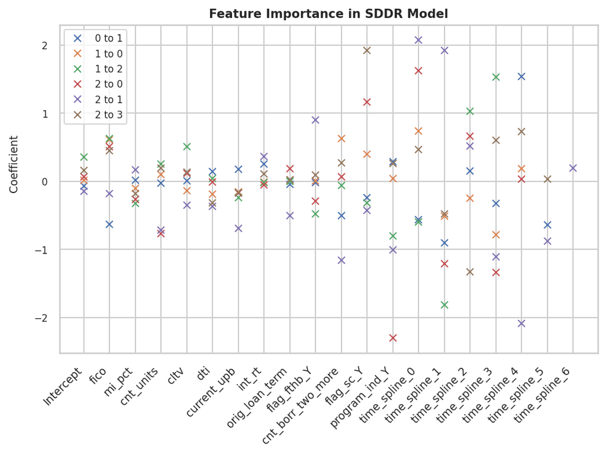

```python
# plot: feature importance
labels = ['0 to 1', '1 to 0', '1 to 2', '2 to 0', '2 to 1', '2 to 3']
plt.rcParams['figure.figsize'] = (8, 5)
plt.rcParams['figure.dpi'] = 150
fig, ax = plt.subplots()
fig.text(0.06, 0.5, 'Coefficient', ha='center', rotation='vertical', fontsize=9)
ax.set_title('Feature Importance in SDDR Model', fontweight='bold', fontsize=10)
ax.tick_params(axis='y', labelsize=8)
ax.set_xticks(np.arange(len(feat[:-1])+max_spline_df), feat[:-1]+[f'time_spline_{i}' for i in range(max_spline_df)], rotation=45, size=9, ha='right')
for i, event in enumerate(events):
    ax.plot(np.arange(len(feat[:-1])+coeff[event][-1].shape[0]), np.concatenate([x.ravel() for x in coeff[event]]), 'x', label=labels[i])
    ax.legend(loc='upper left', fontsize=8)
fig.savefig("SDDR_outputs/feature_importance.png")
fig.show()
```

```python
# calculate the baseline probabilities for each transition event
spline_effects = {}
time = {}
for event in events:
    spline_effects[event] = best_estimator_nn[event].sddr_.eval('logits', plot=False)
    spline_effects[event] = np.vstack(spline_effects[event][0][:]).T
    spline_effects[event] = spline_effects[event][np.argsort(spline_effects[event][:,0])]
    time[event] = spline_effects[event][:,0]
    spline_effects[event] = spline_effects[event][:,1:]
    spline_effects[event] = spline_effects[event] + coeff[event][0]
    spline_effects[event] = expit(spline_effects[event])
```

The next plot presents baseline transition probabilities, i.e., the sum of the coefficients of splines time the basis functions and the intercept. The conditions are the same as those listed in the benchmark section. Splines for the transition from state $0$ to $1$ show an almost identical pattern as those in the benchmark, even though the polynomials are quadratic. The curve for the transition from state $1$ to $0$ also resembles the one in the benchmark, but the curve is translated down by about $0.1$. The other four splines show very different changes of curvature than the ones in the benchmark. These newly fitted splines have much higher fluctuations. Possible reasons for the differences will be discussed in Section 6. Conclusions and Discussions.

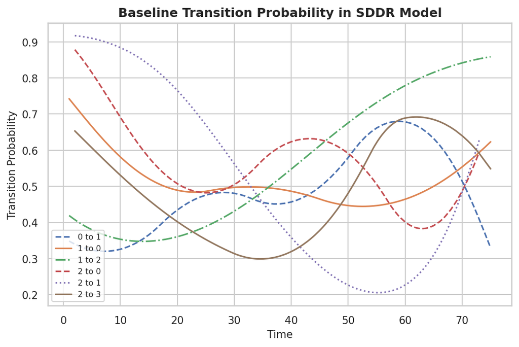

```python
# plot: baseline transition probabilities
labels = ['0 to 1', '1 to 0', '1 to 2', '2 to 0', '2 to 1', '2 to 3']
markers = ['--', '-', '-.', '--', ':', '-']
fig, ax = plt.subplots()
plt.rcParams['figure.figsize'] = (12, 6)
plt.rcParams['figure.dpi'] = 120
plt.title('Baseline Transition Probability in SDDR Model', fontweight='bold', fontsize=12)
plt.xticks(size=10)
plt.yticks(size=10)
plt.xlabel('Time', fontsize=10)
plt.ylabel('Transition Probability', fontsize=10)
for i, event in enumerate(events):
    ax.plot(time[event], spline_effects[event][:,0], markers[i], label=labels[i])
    ax.legend(loc='lower left')
fig.savefig("SDDR_outputs/baseline_transition.png")
plt.show()
```

```python
# calculate fpr, tpr, and auc
# warning: this will take approximately 6 mins to run
fpr, tpr, auc = {}, {}, {}

dfs_test_merged['event_0*']["event_01_pred_probs"] = 0
for index_subset in np.array_split(dfs_test_merged['event_0*'].index, 20):
    _ = best_estimator_nn['event_01'].score(X=dfs_test_merged['event_0*'].loc[index_subset,:], y=test_y['event_01'].loc[index_subset,:])
    dfs_test_merged['event_0*'].loc[index_subset, "event_01_pred_probs"] = best_estimator_nn['event_01'].pred_proba_

fpr['event_01'], tpr['event_01'], _ = roc_curve(y_true=test_y['event_01'], y_score=dfs_test_merged['event_0*']['event_01_pred_probs'])
auc['event_01'] = roc_auc_score(y_true=test_y['event_01'], y_score=dfs_test_merged['event_0*']['event_01_pred_probs'])

for event in events[1:]:
    sts = f"{event[:-1]}*"
    auc[event] = best_estimator_nn[event].score(X=dfs_test_merged[sts], y=test_y[event])
    fpr[event], tpr[event], _ = roc_curve(y_true=test_y[event], y_score=best_estimator_nn[event].pred_proba_)
    dfs_test_merged[sts][f"{event}_pred_probs"] = best_estimator_nn[event].pred_proba_
```

#### 4.2.4 Performance Analysis

The ROC curves below clearly show that except for the model predicting the probabilities of transition from state $0$ to $1$, the other SDDR models perform less well than the benchmark logistic models. The overall accuracy across all transition events is however higher with 66% compared to 60%. The next cells compute the competing probabilities and the overall accuracy.

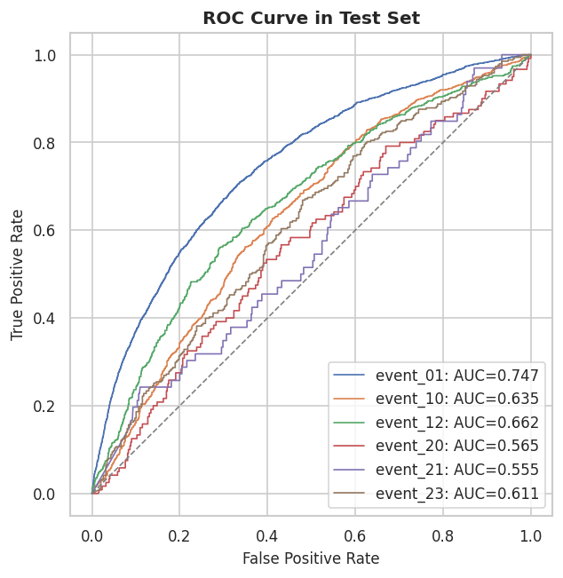

```python
# plot: roc curves
fig, ax = plt.subplots()
plt.rcParams['figure.figsize'] = (5, 5)
plt.title('ROC Curve in Test Set', fontweight='bold', fontsize=12)
plt.xticks(size=10); plt.yticks(size=10)
plt.xlabel('False Positive Rate', fontsize=10)
plt.ylabel('True Positive Rate', fontsize=10)
for event in events:
    ax.axis('equal')
    ax.set_aspect('equal', adjustable='box')
    ax.plot(fpr[event], tpr[event], linewidth=1, label=f'{event}: AUC={auc[event]:.3f}')
    ax.legend(loc='lower right', fontsize=10)
plt.plot([0,1], [0,1], linewidth=1, color='gray', linestyle='--')
fig.savefig("SDDR_outputs/roc_curve_auc.png")
plt.show()
```

```python
# calculate competing transition probabilities
dfs_test_merged['event_0*']['event_01_competing_probs'] = dfs_test_merged['event_0*']['event_01_pred_probs']
dfs_test_merged['event_0*']['event_00_competing_probs'] = 1 - dfs_test_merged['event_0*']['event_01_competing_probs']
dfs_test_merged['event_1*']['event_10_competing_probs'] = dfs_test_merged['event_1*']['event_10_pred_probs'] * (1 - dfs_test_merged['event_1*']['event_12_pred_probs'] / 2)
dfs_test_merged['event_1*']['event_12_competing_probs'] = dfs_test_merged['event_1*']['event_12_pred_probs'] * (1 - dfs_test_merged['event_1*']['event_10_pred_probs'] / 2)
dfs_test_merged['event_1*']['event_11_competing_probs'] = 1 - dfs_test_merged['event_1*']['event_10_competing_probs'] - dfs_test_merged['event_1*']['event_12_competing_probs']
dfs_test_merged['event_2*']['event_20_competing_probs'] = dfs_test_merged['event_2*']['event_20_pred_probs'] * (1 - (dfs_test_merged['event_2*']['event_21_pred_probs'] + dfs_test_merged['event_2*']['event_23_pred_probs']) / 2 + (dfs_test_merged['event_2*']['event_21_pred_probs'] * dfs_test_merged['event_2*']['event_23_pred_probs']) / 3)
dfs_test_merged['event_2*']['event_21_competing_probs'] = dfs_test_merged['event_2*']['event_21_pred_probs'] * (1 - (dfs_test_merged['event_2*']['event_20_pred_probs'] + dfs_test_merged['event_2*']['event_23_pred_probs']) / 2 + (dfs_test_merged['event_2*']['event_20_pred_probs'] * dfs_test_merged['event_2*']['event_23_pred_probs']) / 3)
dfs_test_merged['event_2*']['event_23_competing_probs'] = dfs_test_merged['event_2*']['event_23_pred_probs'] * (1 - (dfs_test_merged['event_2*']['event_20_pred_probs'] + dfs_test_merged['event_2*']['event_21_pred_probs']) / 2 + (dfs_test_merged['event_2*']['event_20_pred_probs'] * dfs_test_merged['event_2*']['event_21_pred_probs']) / 3)
dfs_test_merged['event_2*']['event_22_competing_probs'] = 1 - dfs_test_merged['event_2*']['event_20_competing_probs'] - dfs_test_merged['event_2*']['event_21_competing_probs'] - dfs_test_merged['event_2*']['event_23_competing_probs']
```

```python
# predict next delinquency statuses
competing_probs0 = [f'event_{trans}_competing_probs' for trans in ['00','01']]
competing_probs1 = [f'event_{trans}_competing_probs' for trans in ['10','11', '12']]
competing_probs2 = [f'event_{trans}_competing_probs' for trans in ['20','21', '22', '23']]
previous_sts = ['event_0*', 'event_1*', 'event_2*']
for sts in previous_sts:
    dfs_test_merged[sts]['pred_sts'] = pd.DataFrame(dfs_test_merged[sts][eval(f'competing_probs{sts[-2]}')].to_numpy().argmax(axis=1), columns=['pred_sts'], index=dfs_test_merged[sts].index)
```

```python
# calculate overall accuracy
correct_obs = 0
total_obs = 0
for sts in previous_sts:
    correct_obs += (dfs_test_merged[sts]['pred_sts'] == dfs_test_merged[sts]['delq_sts']).sum()
    total_obs += dfs_test_merged[sts].shape[0]
print(f'The overall prediction accuracy of the SDDR models on the test sets is {100 * correct_obs / total_obs :.3f}%.')
```

```
The overall prediction accuracy of the SDDR models on the test sets is 66.008%.
```

Following are the training loss graphs for the six SDDR models. Unfortunately, it has not yet been investigated why the losses for `event_01` look so strange due to time constraints.

[figure not shown]

Training and validation losses for modeling transition from state 0 to 1

[figure not shown]

Training and validation losses for modeling transition from state 1 to 0

[figure not shown]

Training and validation losses for modeling transition from state 1 to 2

[figure not shown]

Training and validation losses for modeling transition from state 2 to 0

[figure not shown]

Training and validation losses for modeling transition from state 2 to 1

[figure not shown]

Training and validation losses for modeling transition from state 2 to 3

## 5. Alternative Approaches

In this section, several alternative approaches to multistate modelingwill be presented. All of these methods can be applied to the dataset that we have analyzed in our notebook. However, they differ from the previous models in how they handle the input data. In benchmark and SDDR we considered the observations as independent, i.e, there was no dependence structure among different observations from the same loan. On the other hand, the methods described in this section are designed to leverage the sequential nature of the multistate problems by modeling conditional probability. In this way, these methods are able to identify the sequential patterns embedded in the feature space along the temporal dimension.

### 5.1 RNN-based architectures

Methods that are based on recurrent neural networks (RNNs) are very interesting techniques for handling time-to-event problems. Due to their recurrent structure, these networks are capable of condensing information from the previous inputs and encoding conditional probability. In 2018, Giunchiglia et al. proposed RNN-SURV, a neural architecture based on RNN to estimate patients' survival chances. The goal of their paper was twofold. Firstly, the authors intended to compute the survival function for each patient and by doing they were able to produce individual survival curves. Secondly, the model was created to also output a risk score for each patient through the linear combination of the survival probabilities. Even though the model assumed time-invariant effects of the covariates, this approach can easily handle and possibly also take advantage of time-varying covariates (TVCs). Essentially, any dataset can be turned into a sequence by adding time as TVC and that was the approach of the Giunchiglia et al. (2018). By dividing the maximal observed time into K intervals, the authors were able to transform the survival analysis problem into a series of binary decision problems. The method was tested on five publicly available datasets from the medical field. Even though the datasets contained only time-independent covariates, the results showed that the RNN-based approach was outperforming other techniques, such as Random Survival Forest or DeepSurv (Katzman et al., 2018). In the wake of these promising results, other works have also used RNNs for survival modeling; see for example DRSA model by Ren et al. (2019) or work by Li et al. (2022).

#### 5.1.1 Adapting our dataset to RNN-based architecture

The approach used in RNN-SURV can be generalized to the multistate intensity problem by considering a number of separate binary transitions and then computing the competing risks, as we did in our previous approaches. In order to adapt our dataset to this method, as in the case of benchmark and SDDR, we first need to divide the whole dataset into six parts (for each transition). Next, in each of these subsets, the observations would have to be grouped by `id_loan`. Consequently, this would create datasets consisting of variable-length sequences, as different loans have different recorded duration. Importantly, the same `id_loan` entering a given subset at different times would need to be considered as a separate observation. Take as an example loan with id `F15Q40320652`. This loan has changed the delinquency state multiple times and whenever this loan transitions to a new state, a new sequence should be created.

This is illustrated in the code below:

```python
df_merge[(df_merge.id_loan == 'F15Q40320652') & (df_merge.delq_sts > 0)]
```

|  | id_loan | current_upb | delq_sts | time | event_01 | event_10 | event_12 | event_21 | event_20 | event_23 | cltv | cnt_units | dti | fico | int_rt | ltv | mi_pct | orig_loan_term | orig_upb | flag_fthb | occpy_sts | channel | prop_type | loan_purpose | cnt_borr | seller_name | servicer_name | flag_sc | pre_harp | … |
| --- | --- | --- | --- | --- | --- | --- | --- | --- | --- | --- | --- | --- | --- | --- | --- | --- | --- | --- | --- | --- | --- | --- | --- | --- | --- | --- | --- | --- | --- | --- |
| 2412693 | F15Q40320652 | 52012.62 | 1 | 11 | 1 | 0 | 0 | 0 | 0 | 0 | 44.0 | 1 | 40.0 | 704.0 | 3.625 | 44.0 | 0 | 360 | 53000 | N | P | C | SF | P | two_more | BANK | BANK | N | N | … |
| 2412694 | F15Q40320652 | 52012.62 | 1 | 12 | 0 | 0 | 0 | 0 | 0 | 0 | 44.0 | 1 | 40.0 | 704.0 | 3.625 | 44.0 | 0 | 360 | 53000 | N | P | C | SF | P | two_more | BANK | BANK | N | N | … |
| 2412706 | F15Q40320652 | 50677.63 | 1 | 24 | 1 | 0 | 0 | 0 | 0 | 0 | 44.0 | 1 | 40.0 | 704.0 | 3.625 | 44.0 | 0 | 360 | 53000 | N | P | C | SF | P | two_more | BANK | BANK | N | N | … |
| 2412713 | F15Q40320652 | 49879.54 | 1 | 31 | 1 | 0 | 0 | 0 | 0 | 0 | 44.0 | 1 | 40.0 | 704.0 | 3.625 | 44.0 | 0 | 360 | 53000 | N | P | C | SF | P | two_more | BANK | BANK | N | N | … |
| 2412726 | F15Q40320652 | 48619.53 | 1 | 44 | 1 | 0 | 0 | 0 | 0 | 0 | 44.0 | 1 | 40.0 | 704.0 | 3.625 | 44.0 | 0 | 360 | 53000 | N | P | C | SF | P | two_more | BANK | BANK | N | N | … |
| 2412728 | F15Q40320652 | 48376.30 | 1 | 46 | 1 | 0 | 0 | 0 | 0 | 0 | 44.0 | 1 | 40.0 | 704.0 | 3.625 | 44.0 | 0 | 360 | 53000 | N | P | C | SF | P | two_more | BANK | BANK | N | N | … |
| 2412729 | F15Q40320652 | 48280.73 | 1 | 47 | 0 | 0 | 0 | 0 | 0 | 0 | 44.0 | 1 | 40.0 | 704.0 | 3.625 | 44.0 | 0 | 360 | 53000 | N | P | C | SF | P | two_more | BANK | BANK | N | N | … |
| 2412739 | F15Q40320652 | 46954.10 | 1 | 57 | 1 | 0 | 0 | 0 | 0 | 0 | 44.0 | 1 | 40.0 | 704.0 | 3.625 | 44.0 | 0 | 360 | 53000 | N | P | C | SF | P | two_more | BANK | BANK | N | N | … |

```python
df_merge.iloc[2412724:2412729]
```

|  | id_loan | current_upb | delq_sts | time | event_01 | event_10 | event_12 | event_21 | event_20 | event_23 | cltv | cnt_units | dti | fico | int_rt | ltv | mi_pct | orig_loan_term | orig_upb | flag_fthb | occpy_sts | channel | prop_type | loan_purpose | cnt_borr | seller_name | servicer_name | flag_sc | pre_harp | … |
| --- | --- | --- | --- | --- | --- | --- | --- | --- | --- | --- | --- | --- | --- | --- | --- | --- | --- | --- | --- | --- | --- | --- | --- | --- | --- | --- | --- | --- | --- | --- |
| 2412724 | F15Q40320652 | 48714.08 | 0 | 42 | 0 | 0 | 0 | 0 | 0 | 0 | 44.0 | 1 | 40.0 | 704.0 | 3.625 | 44.0 | 0 | 360 | 53000 | N | P | C | SF | P | two_more | BANK | BANK | N | N | … |
| 2412725 | F15Q40320652 | 48619.53 | 0 | 43 | 0 | 0 | 0 | 0 | 0 | 0 | 44.0 | 1 | 40.0 | 704.0 | 3.625 | 44.0 | 0 | 360 | 53000 | N | P | C | SF | P | two_more | BANK | BANK | N | N | … |
| 2412726 | F15Q40320652 | 48619.53 | 1 | 44 | 1 | 0 | 0 | 0 | 0 | 0 | 44.0 | 1 | 40.0 | 704.0 | 3.625 | 44.0 | 0 | 360 | 53000 | N | P | C | SF | P | two_more | BANK | BANK | N | N | … |
| 2412727 | F15Q40320652 | 48376.30 | 0 | 45 | 0 | 1 | 0 | 0 | 0 | 0 | 44.0 | 1 | 40.0 | 704.0 | 3.625 | 44.0 | 0 | 360 | 53000 | N | P | C | SF | P | two_more | BANK | BANK | N | N | … |
| 2412728 | F15Q40320652 | 48376.30 | 1 | 46 | 1 | 0 | 0 | 0 | 0 | 0 | 44.0 | 1 | 40.0 | 704.0 | 3.625 | 44.0 | 0 | 360 | 53000 | N | P | C | SF | P | two_more | BANK | BANK | N | N | … |

To sum up, in the case of RNN-based methods, regardless of whether a model is similar to RNN-SURV or whether RNN architecture is used within the SDDR model, one would need to transform the dataset so it consists of sequences grouped by `id_loan` as explained above. We can recognize an analogy to Natural Language Processing (NLP), where variations of RNN architectures are widely used. Here, each loan $i$ is like a sentence that consists of multiple "words" which represent a concatenation of numerical features and categorical embeddings describing a loan at a time $t$.

#### 5.1.2 Architecture choices

The authors of RNN-SURV did not publish their code or their implementation of the model. Still, they shared some of the implementation details and included a diagram of the network's architecture that is also presented below.

[figure not shown]

RNN-SURV architecture, work by Giunchiglia et al. (2018)

The architecture consists of a feedforward network that encodes the inputs at a time $t$ and passes it through the LSTM layers. Dropout is applied to both the feedforward and recurrent layers in order to avoid overfitting. To address the vanishing gradient problem, the feedforward layers are composed of ReLU non-linearity and the recurrent layers consist of LSTM cells. The flow of data is as follows: at each time step $t$ the network takes the input features and outputs the conditional probability of the event at that time. Giunchiglia et al. (2018) used two loss functions in their proposed model: a modified cross-entropy function that is able to take into account the censored data and an upper bound of the negative C-index. The choice of the loss function can be modified. One can consult the thesis by Glazier (2019), where different loss functions are used and tested for survival analysis within RNN architectures.

When a recurrent neural network is used to analyze our dataset there is one more issue that needs to be addressed. As mentioned earlier, after the data preparation is completed, we would have datasets consisting of sequences of different lengths. For computational reasons, most of the deep learning frameworks require the sequences to be of the same length. A common solution to this problem is to pad all sequences to be as long as the longest one. This issue was not addressed in the RNN-SURV paper, however, it was stated that the network was trained using mini-batching and Adam optimizer. The aspect of padding sequences in survival problems is covered in the work by Glazier (2019).

### 5.2 Conditional Random Fields

Another approach that could be potentially used to model time-to-event problems and can also utilize deep architectures is a combination of the recurrent neural network (e.g LSTM) with a final layer of conditional random fields (CRF). To the best of our knowledge, this technique has been rarely used in survival analysis tasks. One of the examples of its application is the work by Al-Shedivat et al. (2018), who applied CRFs to the outputs from the neural encoders (MLP-CRF and LSTM-CRF). They used these techniques as the baselines to compare them with proposed in their paper contextual explanation networks (CEN). On the other hand, CRF is successfully used in NLP for sequence labeling tasks such as named entity recognition (Huang et al., 2015) as well as in biological sequence labeling, for example, to predict genes (Culotta et al., 2005). CRF belongs to the family of probabilistic graphical models (PGM) that are used to represent joint distributions over a set of random variables. The method works in the following way: RNN/LSTM is used for feature extraction and latent representation of the data and their outputs are fed into the CRF. The advantage of using CRF is that it can take context into account, unlike a regular classifier. As the CRF layer has a state transition matrix as its parameters it can add some constraints to the final predictions to ensure that they are valid. For a detailed overview of Conditional Random Field, one should review the work of Sutton and McCallum (2006). Also in the case of this architecture, we would have to prepare the data as we explained in the previous section on RNNs, except that now we can use the entire history of each loan. Splitting data into separate problems for each event of interest would not be necessary in this case.

### 5.3 Transformer-based methods and beyond

The natural progression in applying techniques that can leverage the sequential nature of data in survival problems is to employ Transformer architecture (Vaswani et al., 2017). Specifically, in Hu et al. (2021) introduced the encoder part of the Transformer to predict the complements of the hazard function for all times up to predefined hyperparameter $T_{max}$. As the Transformer models were originally designed to solve NLP tasks, also in this case, we have an analogy to sentences and words. In contrast to RNN structures, a Transformer computation is more efficient because it can be parallelized. While discussing Transformer-based approaches, it is also worth mentioning a method that was proposed by Zhao et al. (2021), namely: BERTSurv. This deep learning survival framework applies Bidirectional Encoder Representations from Transformers (BERT) as a language representation model on unstructured clinical notes, for mortality prediction and survival analysis of trauma patients. The idea of using unstructured data in survival and multistate intensity problems could be very beneficial in other fields with an abundance of unstructured data, including the financial and lending sector.

## 6. Conclusions and Discussions

Different models have been developed to model the probability of delinquency or default. The multistate intensity model is a model that not only takes the time factor into account during the modeling but also avoids the assumption that the hazard of each event is independent before one event materializes. The goal of our research is to construct a deep learning model to predict the (competing) probability of transitions among different states of loans under the framework of the multistate intensity model. Because the intensity model can also produce the transition probability for states between up-to-date state and default state, we can obtain a more comprehensive understanding of the progression of the loan. For example, we might be able to identify the factors triggering the movement toward or recovery from a specific delinquency state.

Based on the marginal Bernoulli process, the benchmark and the SDDR models deliver the non-competing transition probabilities, with which we can calculate the competing probabilities and formulate the non-homogenous predicted transition probability matrix. In the benchmark model, the numerical variables contribute less to the modeling of non-competing probabilities than the basis functions of the B-splines. The curves for baseline transition probabilities are smooth under the use of B-splines and have distinct shapes for different events. The effect of `time` can be interpreted from the figure for baseline intensities. The performance of the benchmark model is under par, considering the low AUC and prediction accuracy in the test set(s).

The SDDR models show that some binary variables have a contribution to the probabilities comparable to the splines, although the effects do not persist across different but similar transition events (i.e., not in all transitions from higher states to lower states can the effects of super-conforming loans and participation in advantage programs be seen). Most of the splines in the SDDR models are also different from those in the benchmark. Judging from the AUC scores of the two kinds of models, splines in the benchmark models might be more true to the effects of `time` in reality. The reasons could be the differences in the positions of the internal knots. Instead of setting equidistant knots, the benchmark utilizes the distribution of `time` to determine their positions. The results also suggest b-splines with cubic piecewise polynomials and four knots are general enough and beat cross-validated splines parameters in AUC scores. As mentioned in Section 4.2.4, the performance of the SDDR models is even worse than the benchmark, except for predicting transition from state $0$ to $1$.

One potential factor leading to the low prediction accuracy of the benchmark and SDDR model is that we omit the unobserved heterogeneity (random effect) among each loan account (see e.g. Djeunde & Crook, 2018; McNeil & Wendin, 2006). In other words, we make a strong assumption that accounts with the same features will have identical non-competing probabilities and we ignore the dependence among various observations of one loan account. To include the heterogeneity, we can extend Equation (1) to $$ q_{ihj}(t) = \mathbf{F} \left(\alpha_{hj}(t) + \beta_{hj}^T \mathbf{X}_{ihj}(t) + u_{ihj} \right), $$ where $u_{ihj}$ reflects the random effect that an account $i$ has when it transitions from state $h$ to state $j$ at time $t$. The omission of the random effect in our models is largely due to the difficulties that we encounter during the implementation of generalized linear mixed models in Python. Djeundje and Crook (2018) suggest that exclusion of random effect may lead to a biased estimation of parameters and thus also a wrong prediction of transition probabilities. However, the results from Djeundje and Crook (2018) show that the inclusion of the random effect does not contribute to the prediction accuracy of the model.

Another possible problem underlying our models may be how we handle the class imbalance. In the benchmark model, we try to deal with the imbalance by using AUC in the cross-validation. What’s more, in the benchmark model, we also specify a class weight inversely proportional to class frequency in the dataset. Nevertheless, these strategies seem not to be very helpful given the relatively low prediction accuracy in the test set. In the SDDR models, because of implementation difficulties, class weights are even replaced by over-/under-sampling, which is less desired. One conceivable solution to the problem of imbalance is to use the algorithm proposed by Djeundje and Crook (2018) to calculate the optimal cut-off. Otherwise, we probably should give up using accuracy as a measure for the evaluation of the model altogether and instead make use of cost-sensitive learning to take asymmetric error costs into account.

An improvement to the SDDR models could be to use the recurrent layers in the neural network part to account for the nature of time-varying processes in the transition data. Moreover, as discussed in the section on the RNN-based approach, this modification could allow us to take advantage of the dependence structure embedded in the data and model the conditional transition probabilities conditional on each loan's past. Unfortunately, this approach has not been attempted due to time constraints.

To further enhance the performance of the benchmark or SDDR model, we can probably include variables such as the unemployment rate or the retail price index in the model because these macroeconomic variables (MV) can reflect the economic climate during the lifetime of mortgage loans. Djeundje and Crook (2018) find out that MVs are statistically significant in their intensity models. Bellotti and Crook (2013) suggest that including MVs in their survival model can be helpful in the estimation of default rates and in the stress testing.

Suggestions for future work within multi-state intensity models could also include experimenting with deep architectures combined with a Conditional Random Field layer. However, in comparison to SDDR, such models will lose the interpretability of the covariates, because of the latent representation of the data generated by the neural architecture. Nevertheless, given the importance of making an accurate prediction in survival analysis tasks, it would be interesting to see if such models could deliver more accurate results, even if the interpretability is sacrificed. Furthermore, Transformer architectures deliver outstanding results in a variety of machine learning tasks (including tasks with sequential input), yet their applications to survival analysis remain largely unexplored. The work performed by Hu et al (2021) was not able to outperform fully connected models, however, the model was trained on rather small datasets given the current standards (both of the datasets under consideration in their work have less than 10k of unique sequences). The authors suggest that Transformer could achieve better results if trained on larger datasets. Given that the Freddy Mac dataset contains over 2 million unique loans that will generate event more sequences, this could be very interesting data to be tested with such architecture. Unfortunately, even with this dataset, because of the imbalance of transitions, such a model could also suffer from a lack of sufficient amount of data.

## Reference

Allison, P. D. (1982). Discrete-time methods for the analysis of event histories. Sociological methodology, 13, 61-98.

Al-Shedivat, M., Dubey, A., & Xing, E. P. (2018). Personalized survival prediction with contextual explanation networks. arXiv preprint arXiv:1801.09810. (Al-Shedivat, Dubey & Xing, 2018)

Aminisharifabad, M., Yang, Q. & Wu, X. (2021) A Deep Learning-Based Reliability Model for Complex Survival Data. IEEE Transactions on Reliability, vol. 70, no. 1, pp. 73-81, March

Bellotti, T., & Crook, J. (2013). Forecasting and stress testing credit card default using dynamic models. International Journal of Forecasting, 29(4), 563-574.

Broken Axis — Matplotlib 3.5.1 documentation. (n.d.). Matplotlib Documentation. Retrieved January 20, 2022, from https://matplotlib.org/stable/gallery/subplots_axes_and_figures/broken_axis.html

Chawla, N. V., Bowyer, K. W., Hall, L. O., & Kegelmeyer, W. P. (2002). SMOTE: synthetic minority over-sampling technique. Journal of artificial intelligence research, 16, 321-357.

Culotta, A., Kulp, D., & McCallum, A. (2005). Gene prediction with conditional random fields. University of Massachusetts, Amherst, Tech. Rep. UM-CS-2005-028.

Danacica, D. E., & Babucea, A. G. (2010). Using survival analysis in economics. survival, 11, 15.

Dickson, D. C., Hardy, M. R., & Waters, H. R. (2019). Actuarial mathematics for life contingent risks. Cambridge University Press.

Djeundje, V. B., & Crook, J. (2018). Incorporating heterogeneity and macroeconomic variables into multistate delinquency models for credit cards. European Journal of Operational Research, 271(2), 697-709.

Giunchiglia, E., Nemchenko, A., & Schaar, M.V. (2018). RNN-SURV: A Deep Recurrent Model for Survival Analysis. ICANN.

Glazier, S. W. (2019). Sequential Survival Analysis with Deep Learning.

Graves, A. (2013). Generating sequences with recurrent neural networks. arXiv preprint arXiv:1308.0850.

Groha, S., Schmon, S. M., & Gusev, A. (2020). A general framework for survival analysis and multistate modeling arXiv preprint arXiv:2006.04893.

Hougaard, P. (1999). Multi-state Models: A Review. Lifetime Data Anal 5, 239–264 https://doi.org/10.1023/A:1009672031531

Hu, S., Fridgeirsson, E., Wingen, G.v. & Welling, M.. (2021). Transformer-Based Deep Survival Analysis. Proceedings of AAAI Spring Symposium on Survival Prediction - Algorithms, Challenges, and Applications 2021, in Proceedings of Machine Learning Research 146:132-148 Available from https://proceedings.mlr.press/v146/hu21a.html.

Huang, Z., Xu, W., & Yu, K. (2015). Bidirectional LSTM-CRF models for sequence tagging. arXiv preprint arXiv:1508.01991.

Jing, H., & Smola, A. J. (2017). Neural Survival Recommender. Proceedings of the Tenth ACM International Conference on Web Search and Data Mining. https://doi.org/10.1145/3018661.3018719

Katzman, J. L., Shaham, U., Cloninger, A., Bates, J., Jiang, T., & Kluger, Y. (2018). DeepSurv: personalized treatment recommender system using a Cox proportional hazards deep neural network. BMC Medical Research Methodology, 18(1). https://doi.org/10.1186/s12874-018-0482-1

Li, X., Krivtsov, V., & Arora, K. (2022). Attention-based deep survival model for time series data. Reliability Engineering & System Safety, 217, 108033. https://doi.org/10.1016/j.ress.2021.108033

Leow, M., & Crook, J. (2014). Intensity models and transition probabilities for credit card loan delinquencies. European Journal of Operational Research, 236(2), 685-694.

Luo, S., Kong, X., & Nie, T. (2016). Spline based survival model for credit risk modeling. European Journal of Operational Research, 253(3), 869-879.

Luptáková, I. D., & Bilíková, M. (2014). Actuarial modeling of life insurance using decrement models. Journal of Applied Mathematics, Statistics and Informatics, 10(1), 81-91.

Manzini, G., Ettrich, T. J., Kremer, M., Kornmann, M., Henne-Bruns, D., Eikema, D. A., Schlattmann, P., & de Wreede, L. C. (2018). Advantages of a multistate approach in surgical research: how intermediate events and risk factor profile affect the prognosis of a patient with locally advanced rectal cancer. BMC Medical Research Methodology, 18(1). https://doi.org/10.1186/s12874-018-0476-z

McNeil, A. J., & Wendin, J. P. (2007). Bayesian inference for generalized linear mixed models of portfolio credit risk. Journal of Empirical Finance, 14(2), 131-149.

Ren, K., Qin, J., Zheng, L., Yang, Z., Zhang, W., Qiu, L., & Yu, Y. (2019). Deep Recurrent Survival Analysis. Proceedings of the AAAI Conference on Artificial Intelligence, 33, 4798–4805. https://doi.org/10.1609/aaai.v33i01.33014798

Rigby, R. A., & Stasinopoulos, D. M. (2005). Generalized additive models for location, scale and shape. Journal of the Royal Statistical Society: Series C (Applied Statistics), 54(3), 507-554.

Rügamer, D., Kolb, C., Fritz, C., Pfisterer, F., Bischl, B., Shen, R., C., Thalmeier, D., Baumann, P., Klein, N. & Müller, C. L. (2021). deepregression: a Flexible Neural Network Framework for Semi-Structured Deep Distributional Regression. arXiv preprint arXiv:2104.02705.

Rügamer, D., Kolb, C., & Klein, N. (2020). Semi-structured deep distributional regression: Combining structured additive models and deep learning. arXiv preprint arXiv:2002.05777.

Sutton, C., & McCallum, A. (2006). An introduction to conditional random fields for relational learning. Introduction to statistical relational learning, 2, 93-128.

Vaswani, A., Shazeer, N., Parmar, N., Uszkoreit, J., Jones, L., Gomez, A. N., Kaiser, L. & Polosukhin, I. (2017). Attention is all you need. Advances in neural information processing systems, 30.

Wood, S. N. (2017). Generalized additive models: an introduction with R. chapman and hall/CRC.

Yu, C. N., Greiner, R., Lin, H. C., & Baracos, V. (2011). Learning patient-specific cancer survival distributions as a sequence of dependent regressors. Advances in neural information processing systems, 24.